# Predicting information integration in pragmatic word learning across development

Probabilistic Models

Manuel Bohn, Michael Henry Tessler, Megan Merrick and Michael C. Frank

# Overview

This file includes model code for the probabilistic models. The section Model code gives the code for the basic integration model. Firs, we define the objects and locations that feature in the experiments along with some helper functions and then we specify the actual cognitive model.

The section Adults presents the analysis code for Experiment 3 and 4. In the section Inferring speaker optimality parameter and setting priors, we estimated the speaker optimality parameter $\alpha$ based on the data from Experiment 1 and define the prior distribution over objects, $P(r)$, based on Experiment 2.

Then follows the code with which we generated the model predictions for the models in Experiment 3, that is, the integration model (with and without a noise parameter), the no informativeness model and the no common ground model (Section: Model predictions). Next, we evaluate the noise parameter for each model and plot the model predictions and correlate predictions and the data for each model (Section: Compare model predictions to data). Finally, we compute the log-likelihoods for each model and the Bayes Factors for the model comparisons (Section: Model comparison).

We start the section on Experiment 4 with specifying $P(r)$ for each version of prior strength manipulations. Next, we generate predictions for the three models (Section: Model predictions (including noise parameter), inspect the corresponding noise parameters, and correlate the model predictions with the data (Section: Compare model predictions to data). Finally, we compute the log-likelihoods and Bayes Factors (Section: Model comparison).

The section Children follows the same logic as the one for adults. We first present the code used to estimate the intercept and slope necessary to compute $\alpha$ (using the data from Experiment 5) and $P(r)$ (using the data from Experiment 6) in an age-sensitive way (Section: Model parameters and data). Then we generate model predictions for the three models, each in three versions,: without a noise parameter, with a single noise parameter and with a developmentally changing noise parameter (Section: Model predictions). Then we compare the different noise parameters and correlate model predictions with the data (Section: Compare model predictions to data). Finally, we compute the log-likelihoods for the different models and compare them via Bayes Factors (Section: Model comparison).

# Model code

## Model utilities

```r
rsaUtils <- '
// three objects: triangle_1 on table 1, triangle_2 and circle_1 on table 2
var all_objects = [
{ shape: "triangle", id:1, location: 1},
{ shape: "triangle", id:2, location: 2},
{ shape: "circle", id:1, location: 2}
]

// listener prior is over types, not tokens (we use uniformDraw on prior_objects)
var prior_objects = [
{ shape: "triangle", id:1, location: 1},
{ shape: "circle", id:1, location: 2}
]

var labels = ["dax","wug"]

// two possible lexica, corresponding to meaning of words "dax" and "wug"
var lexicon1 = function(utterance, obj){
utterance.label == "dax" ? obj.shape == "triangle" :
utterance.label == "wug" ? obj.shape == "circle" :
true
}

var lexicon2 = function(utterance, obj){
utterance.label == "dax" ? obj.shape == "circle" :
utterance.label == "wug" ? obj.shape == "triangle" :
true
}

var lexiconObjects = {
"dax = triangle": {
triangle: "dax", circle: "wug"
},
"dax = circle": {
triangle: "wug", circle: "dax"
},
}

var lexiconObject = {
"dax = triangle": lexicon1,
"dax = circle" : lexicon2
}

var point = function(utterance, obj){
return obj.location == utterance.point
}


var utterancePrior = function(obj, lexiconName){
  var locationsWithShape = _.map(_.filter(all_objects, {shape: obj.shape}), "location")
  var point = uniformDraw(locationsWithShape)
  var label = lexiconObjects[lexiconName][obj.shape]
  return {label: label, point: point}
}

var LexiconPrior = Categorical({vs: ["dax = triangle","dax = circle" ], ps: [1, 1]})

var addNoise = function(dist, noiseParam){
   Infer({model: function(){
      return flip(noiseParam) ? uniformDraw([0, 1]) : sample(dist)
    }
   })
}

var foreach = function(fn, lst) {
    var foreach_ = function(i) {
        if (i < lst.length) {
            fn(lst[i]);
            foreach_(i + 1);
        }
    };
    foreach_(0);
};

var logistic = function(x) {1 / (1 + Math.exp(-x))}

var levels = function(df, label){
  return _.uniq(_.map(df, label));
}

'
```

## RSA model code

```r
rsaModel <- '
var literalListener = cache(function(utterance, priorProbs){
  Infer({method: "enumerate", model: function(){
    var lexiconName = sample(LexiconPrior);
    var lexicon = lexiconObject[lexiconName];
    var obj = sample( Categorical({vs: all_objects, ps: priorProbs}));
    if ("label" in utterance) {
      var truthValue = lexicon(utterance, obj);
      condition(truthValue)
    }
    if (utterance.point) {
     var truthValuePoint = point(utterance, obj);
     condition(truthValuePoint)
    }
    return obj.shape
  }})
})

var speaker = cache(function(obj, lexiconName, priorProbs, speakerOptimality){
  Infer({method: "enumerate", model: function(){
    var utterance = utterancePrior(obj, lexiconName);
    var L0 = literalListener(utterance, priorProbs);
    factor(speakerOptimality * L0.score(obj.shape))
    return utterance
  }})
})

var pragmaticListener = cache(function(utterance, priorProbs, speakerOptimality){
  Infer({method: "enumerate", model: function(){
    var lexiconName = sample(LexiconPrior);
    var obj = sample( Categorical({vs: all_objects, ps: priorProbs}));
    var S1 = speaker(obj, lexiconName, priorProbs, speakerOptimality);
    observe(S1, utterance)
    return obj.shape == "circle" ? 1 : 0
  }})
})

var addNoise = function(dist, noiseParam){
   Infer({model: function(){
      return flip(noiseParam) ? uniformDraw([0, 1]) : sample(dist)
    }
   })
}
'
```

# Adults

## Experiment 3

### Model parameters and data

```r
# load data from experiment 3
adult_ex3_data <-read_csv(file="../../stats/data/adult_ex3.csv")
```

```r
# adults exp 1
adult_ex1_data <- read_csv(file="../../stats/data/adult_ex1.csv")
# load data from prior manipulation experiments to set priors
adult_ex2_novelty_data <- read_csv(file="../../stats/data/adult_ex2_novelty.csv")
adult_ex2_preference_data <- read_csv(file="../../stats/data/adult_ex2_preference.csv")
```

#### Inferring speaker optimality parameter and setting priors

```r
# Cauchy prior on the speaker optimality parameter around 1, based on previous work (e.g. Frank & Goodman, 2014)
speakOptParam <- '
var data = dataFromR.data

var model  = function(){

  var speakerOptimality = sample(Cauchy({location: 1, scale: 2}))

  foreach(function(row){

    var priorProbs = [.5, .5, .5]

    var rsaPredictions = pragmaticListener({label: "dax", point: 2 },
      priorProbs, speakerOptimality)

    observe(rsaPredictions, row.correct)
  }, data)

  return speakerOptimality

}
'
```

```r
# adult_model_param<- webppl(
#   program_code = paste(rsaUtils, rsaModel, speakOptParam , sep='\n'),
#   data = list(data = adult_ex1_data %>% filter(condition == "test")),
#   data_var = "dataFromR",
#   model_var = "model",
#   chains = 4,
#   cores = 4,
#   inference_opts = list(method = "MCMC", samples = 6000, burn = 2000, verbose = T)
# )%>%
#   saveRDS("../../stats/saves/adult_model_param.rds")


adult_model_param <- readRDS("../../stats/saves/adult_model_param.rds")%>%
  select(value) %>%
  summarise(so_map = estimate_mode(value),
            ci_lower = hdi_lower(value),
            ci_upper = hdi_upper(value))
```

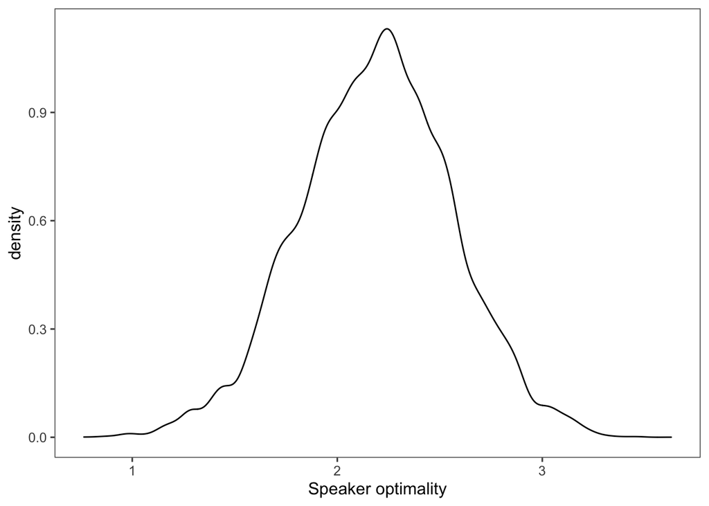

```r
# visualize speaker optimality parameter
plot_adult_model_speak_opt <- readRDS("../../stats/saves/adult_model_param.rds")%>%
  select(value)

ggplot(plot_adult_model_speak_opt, aes(value))+
  geom_density()+
  xlab("Speaker optimality")+
  theme_few()
```

```r
# create datafiles with model parameters
model_params_ex3 <- expand.grid(
  common_ground_manipulation = c("preference", "novelty"),
  speaker = c("same_speaker", "different_speaker"),
  speak_opt = adult_model_param$so_map
  )

prior_pref_summary <- bind_rows(
  adult_ex2_preference_data,
  adult_ex2_novelty_data) %>%
  group_by(condition, experiment) %>%
  summarise(prior = mean(correct)) %>%
  mutate(experiment = gsub("adult_ex2_", "", experiment)) %>%
  rename(common_ground_manipulation = experiment,
         speaker = condition)

model_params_ex3 <- left_join(
  model_params_ex3,
  prior_pref_summary, by = c("common_ground_manipulation", "speaker")
) %>%
  rename(congruent = prior) %>%
  mutate(incongruent = 1 - congruent) %>%
  gather(alignment, prior, congruent, incongruent)
```

### Model predictions

#### Integration model

##### Parameter free

```r
predictions.rsa.ex3 <-'

var allData = dataFromR.data

var output = map(function(row){

    var priorProbLst = [1 - row.prior, 1 - row.prior, row.prior]

    var modelPredictions = pragmaticListener({label: "dax", point: 2 }, priorProbLst, row.speak_opt)

    return extend([row.common_ground_manipulation + "/" + row.speaker + "/" + row.alignment, Math.exp(modelPredictions.score(1))])

}, allData)

output

'
```

```r
ex3_pragm_model<- webppl(
  program_code = paste(rsaUtils, rsaModel, predictions.rsa.ex3 , sep='\n'),
  data =list(data = model_params_ex3),
  data_var = "dataFromR"
)

# model predictions
ex3_pragm_model_predictions <- ex3_pragm_model %>%
  separate(`0`, into = c("common_ground_manipulation", "speaker", "alignment"), sep="/")%>%
  mutate(value = `1`,
         model="pragmatic")%>%
  select(-`1`)
```

##### Noise parameter

```r
predictions.rsa.ex3.noise <-'
var allParams = dataFromR.allParams
var allData = dataFromR.allData

var model = function(){

   var noise = uniformDrift({a: 0, b:1, width: 0.1})

  var conditionOutput = map(function(conditionInfo){

  var conditionSpecificData =  _.filter(allData, {common_ground_manipulation: conditionInfo.common_ground_manipulation, speaker: conditionInfo.speaker, alignment: conditionInfo.alignment})

   var conditionSpecificPriors = [1 - conditionInfo.prior, 1 - conditionInfo.prior, conditionInfo.prior]

      var modelPredictions = pragmaticListener({label: "dax", point: 2 }, conditionSpecificPriors, conditionInfo.speak_opt)

   var noisyModelPredictions = addNoise(modelPredictions, noise)

 map(function(d){
      observe(noisyModelPredictions, d.correct_inf)
    }, conditionSpecificData)

  return  [conditionInfo.common_ground_manipulation + "/" + conditionInfo.speaker + "/" +  conditionInfo.alignment, Math.exp(noisyModelPredictions.score(1))]

}, allParams)

  return extend(_.fromPairs(conditionOutput), {noise: noise})
}
'
```

```r
# ex3_pragm_model_noise <- webppl(
#   program_code = paste(rsaUtils, rsaModel, predictions.rsa.ex3.noise, sep='\n'),
#   data = list(allData = adult_ex3_data, allParams = model_params_ex3),
#   data_var = "dataFromR",
#   model_var = "model",
#   chains = 4,
#   cores = 4,
#   inference_opts = list(method = "MCMC", samples = 6000, burn = 2000, verbose = T)
# ) %>%
#   saveRDS("../../stats/saves/ex3_pragm_model_noise.rds")


# model predictions
ex3_pragm_model_pred_noise <- readRDS("../../stats/saves/ex3_pragm_model_noise.rds") %>%
  filter(!(Parameter %in% c("noise")))  %>%
  separate(Parameter, into = c("common_ground_manipulation","speaker", "alignment"), sep="/")%>%
  mutate(model="pragmatic_noise")%>%
  group_by(model,common_ground_manipulation,speaker,alignment)%>%
  summarise(mean = estimate_mode(value),
            ci_lower = hdi_lower(value),
            ci_upper = hdi_upper(value))

## noise parameter
ex3_pragm_model_noise_param <- readRDS("../../stats/saves/ex3_pragm_model_noise.rds") %>%
  filter(Parameter %in% c("noise"))  %>%
  summarise(mean = estimate_mode(value),
            ci_lower = hdi_lower(value),
            ci_upper = hdi_upper(value))
```

#### No informativeness model

##### Noise parameter

```r
predictions.prior.only.ex3.noise <-'
var allParams = dataFromR.allParams
var allData = dataFromR.allData

var model = function(){

   var noise = uniformDrift({a: 0, b:1, width: 0.1})

  var conditionOutput = map(function(conditionInfo){

  var conditionSpecificData =  _.filter(allData, {common_ground_manipulation: conditionInfo.common_ground_manipulation, speaker: conditionInfo.speaker, alignment: conditionInfo.alignment})

   var conditionSpecificPriors = [1 - conditionInfo.prior, 1 - conditionInfo.prior, conditionInfo.prior]

  var modelPredictions = Infer({method: "enumerate", model: function(){
      var obj = sample( Categorical({vs: all_objects, ps: conditionSpecificPriors}));
      return obj.shape == "circle" ? 1 : 0
  }})

   var noisyModelPredictions = addNoise(modelPredictions, noise)

 map(function(d){
      observe(noisyModelPredictions, d.correct_inf)
    }, conditionSpecificData)

  return  [conditionInfo.common_ground_manipulation + "/" + conditionInfo.speaker + "/" +  conditionInfo.alignment, Math.exp(noisyModelPredictions.score(1))]

}, allParams)

  return extend(_.fromPairs(conditionOutput), {noise: noise})
}
'
```

```r
# ex3_prior_only_model_noise <- webppl(
#   program_code = paste(rsaUtils, rsaModel, predictions.prior.only.ex3.noise, sep='\n'),
#   data = list(allData = adult_ex3_data, allParams = model_params_ex3),
#   data_var = "dataFromR",
#   model_var = "model",
#   chains = 4,
#   cores = 4,
#   inference_opts = list(method = "MCMC", samples = 6000, burn = 2000, verbose = T)
# ) %>%
#   saveRDS("../../stats/saves/ex3_prior_only_model_noise.rds")


# model predictions
ex3_prior_only_model_pred_noise <- readRDS("../../stats/saves/ex3_prior_only_model_noise.rds") %>%
  filter(!(Parameter %in% c("noise")))  %>%
  separate(Parameter, into = c("common_ground_manipulation","speaker", "alignment"), sep="/")%>%
  mutate(model="prior_only_noise")%>%
  group_by(model,common_ground_manipulation,speaker,alignment)%>%
  summarise(mean = estimate_mode(value),
            ci_lower = hdi_lower(value),
            ci_upper = hdi_upper(value))

## noise parameter
ex3_prior_only_model_noise_param <- readRDS("../../stats/saves/ex3_prior_only_model_noise.rds") %>%
  filter(Parameter %in% c("noise"))  %>%
  summarise(mean = estimate_mode(value),
            ci_lower = hdi_lower(value),
            ci_upper = hdi_upper(value))
```

#### No common ground model

##### Noise parameter

```r
predictions.flat.prior.ex3.noise <-'
var allParams = dataFromR.allParams
var allData = dataFromR.allData

var model = function(){

   var noise = uniformDrift({a: 0, b:1, width: 0.1})

  var conditionOutput = map(function(conditionInfo){

  var conditionSpecificData =  _.filter(allData, {common_ground_manipulation: conditionInfo.common_ground_manipulation, speaker: conditionInfo.speaker, alignment: conditionInfo.alignment})

   var conditionSpecificPriors = [.5, .5, .5]

      var modelPredictions = pragmaticListener({label: "dax", point: 2 }, conditionSpecificPriors, conditionInfo.speak_opt)

   var noisyModelPredictions = addNoise(modelPredictions, noise)

 map(function(d){
      observe(noisyModelPredictions, d.correct_inf)
    }, conditionSpecificData)

  return  [conditionInfo.common_ground_manipulation + "/" + conditionInfo.speaker + "/" +  conditionInfo.alignment, Math.exp(noisyModelPredictions.score(1))]

}, allParams)

  return extend(_.fromPairs(conditionOutput), {noise: noise})
}
'
```

```r
# ex3_flat_prior_model_noise <- webppl(
#   program_code = paste(rsaUtils, rsaModel, predictions.flat.prior.ex3.noise, sep='\n'),
#   data = list(allData = adult_ex3_data, allParams = model_params_ex3),
#   data_var = "dataFromR",
#   model_var = "model",
#   chains = 4,
#   cores = 4,
#   inference_opts = list(method = "MCMC", samples = 6000, burn = 2000, verbose = T)
# ) %>%
#   saveRDS("../../stats/saves/ex3_flat_prior_model_noise.rds")


# model predictions
ex3_flat_prior_model_pred_noise <- readRDS("../../stats/saves/ex3_flat_prior_model_noise.rds") %>%
  filter(!(Parameter %in% c("noise")))  %>%
  separate(Parameter, into = c("common_ground_manipulation","speaker", "alignment"), sep="/")%>%
  mutate(model="flat_prior_noise")%>%
  group_by(model,common_ground_manipulation,speaker,alignment)%>%
  summarise(mean = estimate_mode(value),
            ci_lower = hdi_lower(value),
            ci_upper = hdi_upper(value))

## noise parameter
ex3_flat_prior_model_noise_param <- readRDS("../../stats/saves/ex3_flat_prior_model_noise.rds") %>%
  filter(Parameter %in% c("noise"))  %>%
  summarise(mean = estimate_mode(value),
            ci_lower = hdi_lower(value),
            ci_upper = hdi_upper(value))
```

#### Compare model predictions to data

##### Noise parameters

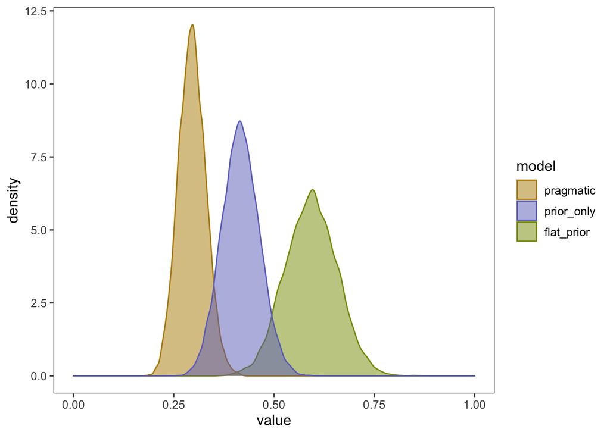

```r
ex3_noise_parameters <- bind_rows(
  readRDS("../../stats/saves/ex3_pragm_model_noise.rds") %>%
  filter(Parameter %in% c("noise"))  %>%
  mutate(model = "pragmatic"),
  readRDS("../../stats/saves/ex3_prior_only_model_noise.rds") %>%
  filter(Parameter %in% c("noise"))  %>%
  mutate(model = "prior_only"),
  readRDS("../../stats/saves/ex3_flat_prior_model_noise.rds") %>%
  filter(Parameter %in% c("noise"))  %>%
  mutate(model = "flat_prior")
  )

ggplot(ex3_noise_parameters, aes(x = value, col = model, fill = model))+
  geom_density(alpha = .5)+
  theme_few()+
  xlim(0,1)+
  scale_color_manual(breaks=c("pragmatic","prior_only","flat_prior"),
                    values= c("#b58900","#6c71c4","#859900"))+
  scale_fill_manual(breaks=c("pragmatic","prior_only","flat_prior"),
                    values= c("#b58900","#6c71c4","#859900"))
```

```r
# combine model predictions with data

# summarize data
adult_ex3_data_summary <- adult_ex3_data %>%
  mutate(model = "data") %>%
  group_by(model,common_ground_manipulation,speaker,alignment)%>%
  summarize(k = sum(correct_inf), n = n())%>%
  ungroup() %>%
  mutate(a = 1 + k,
         b = 1 + n - k,
         ci_lower  = qbeta(.025, a, b),
         ci_upper = qbeta(.975, a, b),
         mean = (a-1)/(a+b-2))%>%
  select(-a,-b,-n,-k)

# summarize model predictions
ex_3_model_pred_param_free <- bind_rows(
  ex3_pragm_model_predictions
)%>%
  group_by(model,common_ground_manipulation,speaker,alignment)%>%
  summarise(mean = mean(value))%>%
  mutate(ci_lower = mean,
         ci_upper = mean)


ex_3_model_pred <-
  bind_rows(
    ex_3_model_pred_param_free,
    ex3_pragm_model_pred_noise,
    ex3_prior_only_model_pred_noise,
    ex3_flat_prior_model_pred_noise)


# combine model predictions and data

ex_3_pred <- bind_rows(
  ex_3_model_pred,
  adult_ex3_data_summary
)


#saveRDS(ex_3_pred, "../../stats/saves/adult_ex3_model_predictions_data.rds")
```

##### Plot model predictions and data

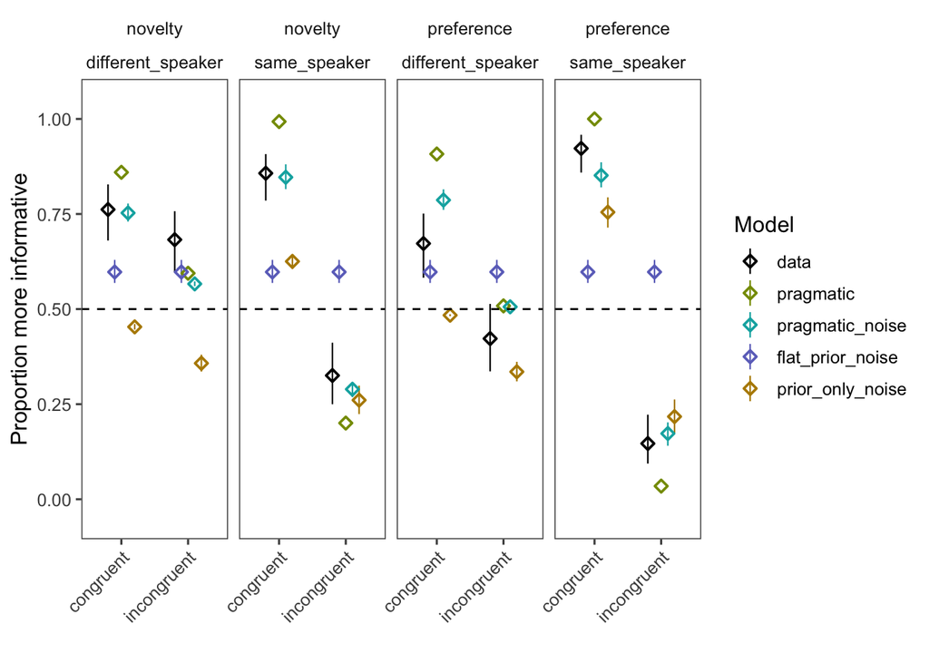

```r
ggplot(data = ex_3_pred, aes(x = alignment, y = mean, col = model)) +
  geom_pointrange(aes(ymin = ci_lower, ymax = ci_upper), size = .4,  position = position_dodge(width = .5), pch = 5)+
  geom_hline(yintercept = 0.5, lty=2)+
  labs(x="",y="Proportion more informative")+
  facet_grid (~ common_ground_manipulation + speaker) +
  theme_few() +
  ylim(-0.05,1.05)+
  guides(alpha = F)+
  scale_color_manual(name="Model",
                     breaks=c("data","pragmatic","pragmatic_noise","flat_prior_noise","prior_only_noise"),
                     values= c("black","#859900","#00afaf","#6c71c4","#b58900"))+
  theme(axis.text.x=element_text(angle = 45, vjust = 1, hjust = 1))
```

##### Correlation plot model predictions and data

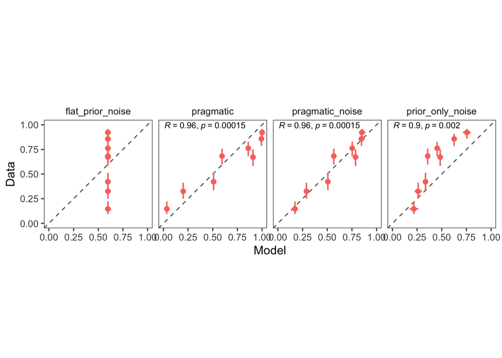

```r
ex_3_cor_plot <- ex_3_pred %>%
  ungroup()%>%
  filter(model != "data") %>%
  left_join(., ex_3_pred %>%
    ungroup()%>%
    filter(model == "data") %>%
    rename(data_mean = mean, data_ci_lower = ci_lower, data_ci_upper = ci_upper) %>%
    select(-model)
  )

ggplot(data = ex_3_cor_plot,aes(x = mean, y = data_mean, col = "#BB5566")) +
  geom_abline(intercept = 0, slope = 1, lty = 2, alpha = 0.7, size = 0.5)+
  geom_point(size = 2)+
  geom_errorbar(aes(ymin = data_ci_lower, ymax = data_ci_upper),width = 0,size = .7)+
  geom_errorbarh(aes(xmin = ci_lower, xmax = ci_upper), height = 0,size = .7)+
  coord_fixed()+
  xlim(0,1)+ylim(0,1)+
  xlab("Model")+
  ylab("Data")+
  guides(col = F)+
  facet_grid ( ~ model) +
  stat_cor(method = "pearson", label.x = 0.01, label.y = 0.99, aes(x = mean, y = data_mean), inherit.aes = F, size = 3)+
  theme_few()
```

### Model comparison

#### Marginal likelihoods

##### Integration model

###### Parameter free

```r
# calculating model log-likelihoods
# log_like_pragmatic_ex3 <- adult_ex3_data %>%
#   left_join(ex3_pragm_model_predictions)%>%
#   mutate(like = ifelse(correct_inf == 1, value, 1 - value),
#          log_like = log(like))%>%
#   group_by(model)%>%
#   summarise(logP = sum(log_like))%>%
#   saveRDS("../../stats/saves/ex3_pragm_model_loglike.rds")

log_like_pragmatic_ex3 <- readRDS("../../stats/saves/ex3_pragm_model_loglike.rds")
```

###### Noise parameter

```r
loglike.rsa.ex3.noise <-'
var allParams = dataFromR.allParams
var allData = dataFromR.allData

var model = function(){

   var noise = uniformDrift({a: 0, b:1, width: 0.1})

  var conditionOutput = map(function(conditionInfo){

  var conditionSpecificData =  _.filter(allData, {common_ground_manipulation: conditionInfo.common_ground_manipulation, speaker: conditionInfo.speaker, alignment: conditionInfo.alignment})

   var conditionSpecificPriors = [1 - conditionInfo.prior, 1 - conditionInfo.prior, conditionInfo.prior]

      var modelPredictions = pragmaticListener({label: "dax", point: 2 }, conditionSpecificPriors, conditionInfo.speak_opt)

   var noisyModelPredictions = addNoise(modelPredictions, noise)

    var loglike = Binomial({
        p: Math.exp(noisyModelPredictions.score(1)),
        n: conditionSpecificData.length}).score(
      sum(_.map(conditionSpecificData, "correct_inf"))
    )
  return  loglike

}, allParams)

 return sum(conditionOutput)

}
'
```

```r
# ex3_pragm_model_noise_loglike <- webppl(
#   program_code = paste(rsaUtils, rsaModel, loglike.rsa.ex3.noise, sep='\n'),
#   data = list(allData = adult_ex3_data, allParams = model_params_ex3),
#   data_var = "dataFromR",
#   model_var = "model",
#   chains = 4,
#   cores = 4,
#   inference_opts = list(method = "forward", samples = 5000)
# ) %>%
#   saveRDS("../../stats/saves/ex3_pragm_model_noise_loglike.rds")

ex3_pragm_model_noise_loglike <- readRDS("../../stats/saves/ex3_pragm_model_noise_loglike.rds")%>%
  mutate(model = "pragmatic_noise")%>%
  group_by(model)%>%
  summarize(logP = logSumExp(value))
```

##### No informativeness model

###### Noise parameter

```r
loglike.prior.only.ex3.noise <-'
var allParams = dataFromR.allParams
var allData = dataFromR.allData

var model = function(){

   var noise = uniformDrift({a: 0, b:1, width: 0.1})

  var conditionOutput = map(function(conditionInfo){

  var conditionSpecificData =  _.filter(allData, {common_ground_manipulation: conditionInfo.common_ground_manipulation, speaker: conditionInfo.speaker, alignment: conditionInfo.alignment})

   var conditionSpecificPriors = [1 - conditionInfo.prior, 1 - conditionInfo.prior, conditionInfo.prior]

  var modelPredictions = Infer({method: "enumerate", model: function(){
      var obj = sample( Categorical({vs: all_objects, ps: conditionSpecificPriors}));
      return obj.shape == "circle" ? 1 : 0
  }})

   var noisyModelPredictions = addNoise(modelPredictions, noise)

    var loglike = Binomial({
        p: Math.exp(noisyModelPredictions.score(1)),
        n: conditionSpecificData.length}).score(
      sum(_.map(conditionSpecificData, "correct_inf"))
    )
  return  loglike

}, allParams)

 return sum(conditionOutput)

}
'
```

```r
# ex3_prior_only_model_noise_loglike <- webppl(
#   program_code = paste(rsaUtils, rsaModel, loglike.prior.only.ex3.noise, sep='\n'),
#   data = list(allData = adult_ex3_data, allParams = model_params_ex3),
#   data_var = "dataFromR",
#   model_var = "model",
#   chains = 4,
#   cores = 4,
#   inference_opts = list(method = "forward", samples = 5000)
# ) %>%
#   saveRDS("../../stats/saves/ex3_prior_only_model_noise_loglike.rds")

ex3_prior_only_model_noise_loglike <- readRDS("../../stats/saves/ex3_prior_only_model_noise_loglike.rds")%>%
  mutate(model = "prior_only_noise")%>%
  group_by(model)%>%
  summarize(logP = logSumExp(value))
```

##### No common ground model

###### Noise parameter

```r
loglike.flat.prior.ex3.noise <-'
var allParams = dataFromR.allParams
var allData = dataFromR.allData

var model = function(){

   var noise = uniformDrift({a: 0, b:1, width: 0.1})

  var conditionOutput = map(function(conditionInfo){

  var conditionSpecificData =  _.filter(allData, {common_ground_manipulation: conditionInfo.common_ground_manipulation, speaker: conditionInfo.speaker, alignment: conditionInfo.alignment})

   var conditionSpecificPriors = [.5, .5,.5]

      var modelPredictions = pragmaticListener({label: "dax", point: 2 }, conditionSpecificPriors, conditionInfo.speak_opt)

   var noisyModelPredictions = addNoise(modelPredictions, noise)

    var loglike = Binomial({
        p: Math.exp(noisyModelPredictions.score(1)),
        n: conditionSpecificData.length}).score(
      sum(_.map(conditionSpecificData, "correct_inf"))
    )
  return  loglike

}, allParams)

 return sum(conditionOutput)

}
'
```

```r
# ex3_flat_prior_model_noise_loglike <- webppl(
#   program_code = paste(rsaUtils, rsaModel, loglike.flat.prior.ex3.noise, sep='\n'),
#   data = list(allData = adult_ex3_data, allParams = model_params_ex3),
#   data_var = "dataFromR",
#   model_var = "model",
#   chains = 4,
#   cores = 4,
#   inference_opts = list(method = "forward", samples = 5000)
# ) %>%
#   saveRDS("../../stats/saves/ex3_flat_prior_model_noise_loglike.rds")

ex3_flat_prior_model_noise_loglike <- readRDS("../../stats/saves/ex3_flat_prior_model_noise_loglike.rds")%>%
  mutate(model = "flat_prior_noise")%>%
  group_by(model)%>%
  summarize(logP = logSumExp(value))
```

```r
ex3_model_comparison <- bind_rows(
  log_like_pragmatic_ex3,
  ex3_pragm_model_noise_loglike,
  ex3_flat_prior_model_noise_loglike,
  ex3_prior_only_model_noise_loglike
)%>%
  mutate(model = reorder(model,logP))
```

#### Plot for likelihoods

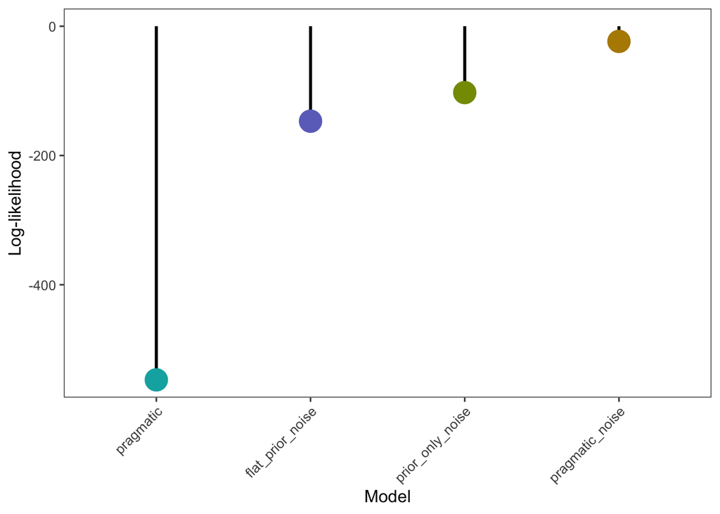

```r
ggplot(ex3_model_comparison, aes(x = model, y = logP, col = model))+
  geom_segment( aes(x=model, xend=model, y=logP, yend=0), col = "black", size = 1)+
  geom_point(size = 7)+
  theme_few()+
  xlab("Model")+
  ylab("Log-likelihood")+
  theme(axis.text.x=element_text(angle = 45, vjust = 1, hjust = 1))+
  guides(col = F)+
  scale_color_manual(breaks=c("pragmatic","pragmatic_noise","prior_only_noise","flat_prior_noise"),
                    values= c("#00afaf","#b58900","#859900","#6c71c4"))
```

#### Bayes factors

```r
ex3_bf <- bind_rows(
  log_like_pragmatic_ex3,
  ex3_pragm_model_noise_loglike,
  ex3_flat_prior_model_noise_loglike,
  ex3_prior_only_model_noise_loglike
) %>% spread(model, logP) %>%
  mutate("pragmatic_noise > pragmatic" = exp(pragmatic_noise - pragmatic),
         "pragmatic_noise > prior_only_noise" = exp(pragmatic_noise - prior_only_noise),
         "pragmatic_noise > flat_prior_noise" = exp(pragmatic_noise - flat_prior_noise),
         "prior_only_noise > flat_prior_noise" = exp(prior_only_noise - flat_prior_noise)) %>%
  select(-pragmatic,-pragmatic_noise, -flat_prior_noise, -prior_only_noise)

ex3_bf %>%
  kable(digits = 2)
```

| pragmatic_noise > pragmatic | pragmatic_noise > prior_only_noise | pragmatic_noise > flat_prior_noise | prior_only_noise > flat_prior_noise |
| --- | --- | --- | --- |
| 2.643141e+227 | 2.492997e+34 | 4.232239e+53 | 1.697652e+19 |

## Experiment 4

### Prior manipulation experiments

### Model parameters and data

```r
# load data  from experiment 4
adult_ex4_data <-read_csv(file="../../stats/data/adult_ex4.csv")
```

```r
# load data from prior strength manipulation experiments to set priors
adult_ex4_prior_data <-read_csv(file="../../stats/data/adult_ex4_prior.csv")
```

```r
# create datafiles with model parameters

ex4Prior <- expand.grid(
  common_ground_manipulation = c("preference","novelty"),
  speaker = c("same_speaker","different_speaker"),
  prior_manipulation = c("strong", "medium", "weak")
)

ex4_prior_summary <- adult_ex4_prior_data %>%
  group_by(common_ground_manipulation, prior_manipulation, speaker) %>%
  summarize(prior = mean(correct))

model_params_ex4 <- left_join(
  ex4Prior,
  ex4_prior_summary
) %>%
  rename(congruent = prior) %>%
  mutate(incongruent = 1 - congruent) %>%
  gather(alignment, prior, congruent, incongruent) %>%
  drop_na() %>%
  mutate(speak_opt = adult_model_param$so_map)
```

### Model predictions (including noise parameter)

#### Integration model

```r
predictions.rsa.ex4.noise <-'
var allParams = dataFromR.allParams
var allData = dataFromR.allData

var model = function(){

   var noise = uniformDrift({a: 0, b:1, width: 0.1})

  var conditionOutput = map(function(conditionInfo){

  var conditionSpecificData =  _.filter(allData, {common_ground_manipulation: conditionInfo.common_ground_manipulation, prior_manipulation: conditionInfo.prior_manipulation, speaker: conditionInfo.speaker, alignment: conditionInfo.alignment})

   var conditionSpecificPriors = [1 - conditionInfo.prior, 1 - conditionInfo.prior, conditionInfo.prior]

      var modelPredictions = pragmaticListener({label: "dax", point: 2 }, conditionSpecificPriors, conditionInfo.speak_opt)

   var noisyModelPredictions = addNoise(modelPredictions, noise)

 map(function(d){
      observe(noisyModelPredictions, d.correct_inf)
    }, conditionSpecificData)

  return  [conditionInfo.common_ground_manipulation + "/" + conditionInfo.prior_manipulation + "/" + conditionInfo.speaker + "/" +  conditionInfo.alignment, Math.exp(noisyModelPredictions.score(1))]

}, allParams)

  return extend(_.fromPairs(conditionOutput), {noise: noise})
}
'
```

```r
# ex4_pragm_model_noise <- webppl(
#   program_code = paste(rsaUtils, rsaModel, predictions.rsa.ex4.noise, sep='\n'),
#   data = list(allData = adult_ex4_data, allParams = model_params_ex4),
#   data_var = "dataFromR",
#   model_var = "model",
#   chains = 4,
#   cores = 4,
#   inference_opts = list(method = "MCMC", samples = 6000, burn = 2000, verbose = T)
# ) %>%
#   saveRDS("../../stats/saves/ex4_pragm_model_noise.rds")


# model predictions
ex4_pragm_model_pred_noise <- readRDS("../../stats/saves/ex4_pragm_model_noise.rds") %>%
  filter(!(Parameter %in% c("noise")))  %>%
  separate(Parameter, into = c("common_ground_manipulation","prior_manipulation","speaker", "alignment"), sep="/")%>%
  mutate(model="pragmatic_noise")%>%
  group_by(model,common_ground_manipulation,prior_manipulation,speaker,alignment)%>%
  summarise(mean = estimate_mode(value),
            ci_lower = hdi_lower(value),
            ci_upper = hdi_upper(value))

## noise parameter
ex4_pragm_model_noise_param <- readRDS("../../stats/saves/ex4_pragm_model_noise.rds") %>%
  filter(Parameter %in% c("noise"))  %>%
  summarise(mean = estimate_mode(value),
            ci_lower = hdi_lower(value),
            ci_upper = hdi_upper(value))
```

#### No informativeness model

```r
predictions.prior.only.ex4.noise <-'
var allParams = dataFromR.allParams
var allData = dataFromR.allData

var model = function(){

   var noise = uniformDrift({a: 0, b:1, width: 0.1})

  var conditionOutput = map(function(conditionInfo){

  var conditionSpecificData =  _.filter(allData, {common_ground_manipulation: conditionInfo.common_ground_manipulation, prior_manipulation: conditionInfo.prior_manipulation, speaker: conditionInfo.speaker, alignment: conditionInfo.alignment})

   var conditionSpecificPriors = [1 - conditionInfo.prior, 1 - conditionInfo.prior, conditionInfo.prior]

  var modelPredictions = Infer({method: "enumerate", model: function(){
      var obj = sample( Categorical({vs: all_objects, ps: conditionSpecificPriors}));
      return obj.shape == "circle" ? 1 : 0
  }})

   var noisyModelPredictions = addNoise(modelPredictions, noise)

 map(function(d){
      observe(noisyModelPredictions, d.correct_inf)
    }, conditionSpecificData)

  return  [conditionInfo.common_ground_manipulation + "/" + conditionInfo.prior_manipulation + "/" + conditionInfo.speaker + "/" +  conditionInfo.alignment, Math.exp(noisyModelPredictions.score(1))]

}, allParams)

  return extend(_.fromPairs(conditionOutput), {noise: noise})
}
'
```

```r
# ex4_prior_only_model_noise <- webppl(
#   program_code = paste(rsaUtils, rsaModel, predictions.prior.only.ex4.noise, sep='\n'),
#   data = list(allData = adult_ex4_data, allParams = model_params_ex4),
#   data_var = "dataFromR",
#   model_var = "model",
#   chains = 4,
#   cores = 4,
#   inference_opts = list(method = "MCMC", samples = 6000, burn = 2000, verbose = T)
# ) %>%
#   saveRDS("../../stats/saves/ex4_prior_only_model_noise.rds")


# model predictions
ex4_prior_only_model_pred_noise <- readRDS("../../stats/saves/ex4_prior_only_model_noise.rds") %>%
  filter(!(Parameter %in% c("noise")))  %>%
  separate(Parameter, into = c("common_ground_manipulation","prior_manipulation","speaker", "alignment"), sep="/")%>%
  mutate(model="prior_only_noise")%>%
  group_by(model,common_ground_manipulation,prior_manipulation,speaker,alignment)%>%
  summarise(mean = estimate_mode(value),
            ci_lower = hdi_lower(value),
            ci_upper = hdi_upper(value))

## noise parameter
ex4_prior_only_model_noise_param <- readRDS("../../stats/saves/ex4_prior_only_model_noise.rds") %>%
  filter(Parameter %in% c("noise"))  %>%
  summarise(mean = estimate_mode(value),
            ci_lower = hdi_lower(value),
            ci_upper = hdi_upper(value))
```

#### No common ground model

```r
predictions.flat.prior.ex4.noise <-'
var allParams = dataFromR.allParams
var allData = dataFromR.allData

var model = function(){

   var noise = uniformDrift({a: 0, b:1, width: 0.1})

  var conditionOutput = map(function(conditionInfo){

  var conditionSpecificData =  _.filter(allData, {common_ground_manipulation: conditionInfo.common_ground_manipulation, prior_manipulation: conditionInfo.prior_manipulation, speaker: conditionInfo.speaker, alignment: conditionInfo.alignment})

   var conditionSpecificPriors = [.5, .5, .5]

      var modelPredictions = pragmaticListener({label: "dax", point: 2 }, conditionSpecificPriors, conditionInfo.speak_opt)

   var noisyModelPredictions = addNoise(modelPredictions, noise)

 map(function(d){
      observe(noisyModelPredictions, d.correct_inf)
    }, conditionSpecificData)

  return  [conditionInfo.common_ground_manipulation + "/" + conditionInfo.prior_manipulation + "/" + conditionInfo.speaker + "/" +  conditionInfo.alignment, Math.exp(noisyModelPredictions.score(1))]

}, allParams)

  return extend(_.fromPairs(conditionOutput), {noise: noise})
}
'
```

```r
# ex4_flat_prior_model_noise <- webppl(
#   program_code = paste(rsaUtils, rsaModel, predictions.flat.prior.ex4.noise, sep='\n'),
#   data = list(allData = adult_ex4_data, allParams = model_params_ex4),
#   data_var = "dataFromR",
#   model_var = "model",
#   chains = 4,
#   cores = 4,
#   inference_opts = list(method = "MCMC", samples = 6000, burn = 2000, verbose = T)
# ) %>%
#   saveRDS("../../stats/saves/ex4_flat_prior_model_noise.rds")


# model predictions
ex4_flat_prior_model_pred_noise <- readRDS("../../stats/saves/ex4_flat_prior_model_noise.rds") %>%
  filter(!(Parameter %in% c("noise")))  %>%
  separate(Parameter, into = c("common_ground_manipulation","prior_manipulation","speaker", "alignment"), sep="/")%>%
  mutate(model="flat_prior_noise")%>%
  group_by(model,common_ground_manipulation,prior_manipulation,speaker,alignment)%>%
  summarise(mean = estimate_mode(value),
            ci_lower = hdi_lower(value),
            ci_upper = hdi_upper(value))

## noise parameter
ex4_flat_prior_model_noise_param <- readRDS("../../stats/saves/ex4_flat_prior_model_noise.rds") %>%
  filter(Parameter %in% c("noise"))  %>%
  summarise(mean = estimate_mode(value),
            ci_lower = hdi_lower(value),
            ci_upper = hdi_upper(value))
```

```r
# combine model predictions with data

# summarize data
adult_ex4_data_summary <- adult_ex4_data %>%
  mutate(prior_manipulation = relevel(as.factor(prior_manipulation), ref = "strong"))%>%
  mutate(model = "data") %>%
  group_by(model,common_ground_manipulation,prior_manipulation,speaker,alignment)%>%
  summarize(k = sum(correct_inf), n = n())%>%
  ungroup() %>%
  mutate(a = 1 + k,
         b = 1 + n - k,
         ci_lower  = qbeta(.025, a, b),
         ci_upper = qbeta(.975, a, b),
         mean = (a-1)/(a+b-2))%>%
  select(-a,-b,-n,-k)

# summarize model predictions
ex_4_model_pred <- bind_rows(
  ex4_pragm_model_pred_noise,
  ex4_prior_only_model_pred_noise,
  ex4_flat_prior_model_pred_noise
)%>%
  ungroup()%>%
  mutate(prior_manipulation = relevel(as.factor(prior_manipulation), ref = "strong"))

# combine model predictions and data

ex_4_pred <- bind_rows(
  ex_4_model_pred,
  adult_ex4_data_summary
)

#saveRDS(ex_4_pred, "../../stats/saves/adult_ex4_model_predictions_data.rds")
```

### Compare model predictions to data

##### Noise parameters

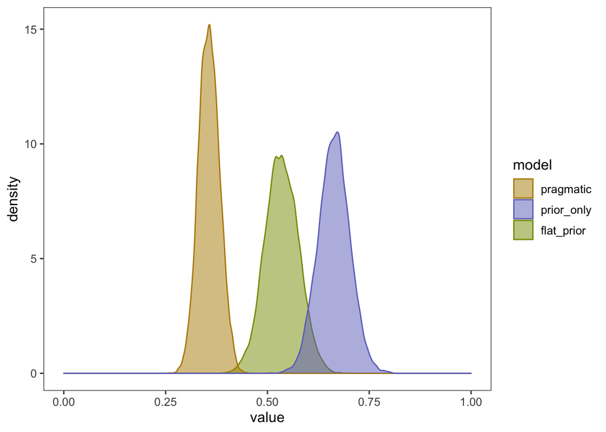

```r
ex4_noise_parameters <- bind_rows(
  readRDS("../../stats/saves/ex4_pragm_model_noise.rds") %>%
  filter(Parameter %in% c("noise"))  %>%
  mutate(model = "pragmatic"),
  readRDS("../../stats/saves/ex4_prior_only_model_noise.rds") %>%
  filter(Parameter %in% c("noise"))  %>%
  mutate(model = "prior_only"),
  readRDS("../../stats/saves/ex4_flat_prior_model_noise.rds") %>%
  filter(Parameter %in% c("noise"))  %>%
  mutate(model = "flat_prior")
  )

ggplot(ex4_noise_parameters, aes(x = value, col = model, fill = model))+
  geom_density(alpha = .5)+
  theme_few()+
  xlim(0,1)+
  scale_color_manual(breaks=c("pragmatic","prior_only","flat_prior"),
                    values= c("#b58900","#6c71c4","#859900"))+
  scale_fill_manual(breaks=c("pragmatic","prior_only","flat_prior"),
                    values= c("#b58900","#6c71c4","#859900"))
```

#### Plot model predictions and data

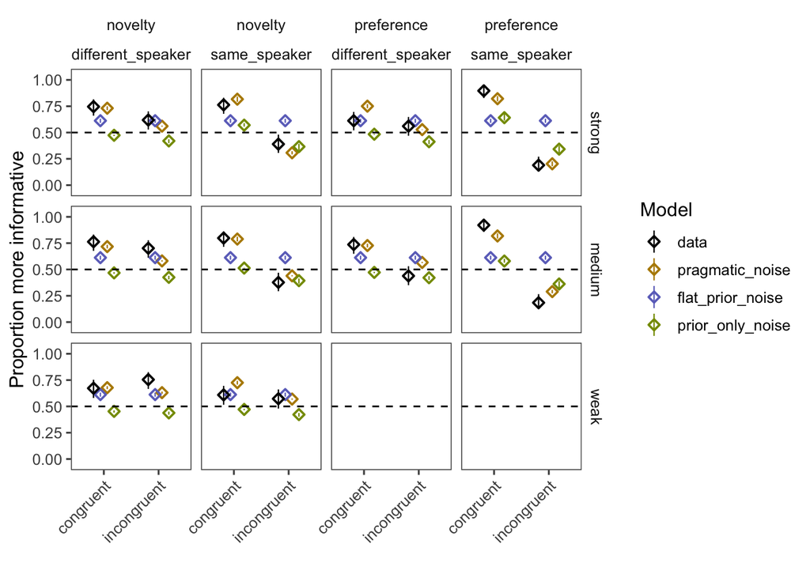

```r
ggplot(data = ex_4_pred, aes(x = alignment, y = mean, col = model)) +
  geom_pointrange(aes(ymin = ci_lower, ymax = ci_upper), size = .4,  position = position_dodge(width = .5), pch = 5)+
  geom_hline(yintercept = 0.5, lty=2)+
  labs(x="",y="Proportion more informative")+
  facet_grid ( prior_manipulation ~ common_ground_manipulation + speaker) +
  theme_few() +
  ylim(-0.05,1.05)+
  guides(alpha = F)+
  scale_color_manual(name="Model",
                     breaks=c("data","pragmatic_noise","flat_prior_noise","prior_only_noise"),
                     values= c("black","#b58900","#6c71c4","#859900"))+
  theme(axis.text.x=element_text(angle = 45, vjust = 1, hjust = 1))
```

#### Correlation plot model predictions and data

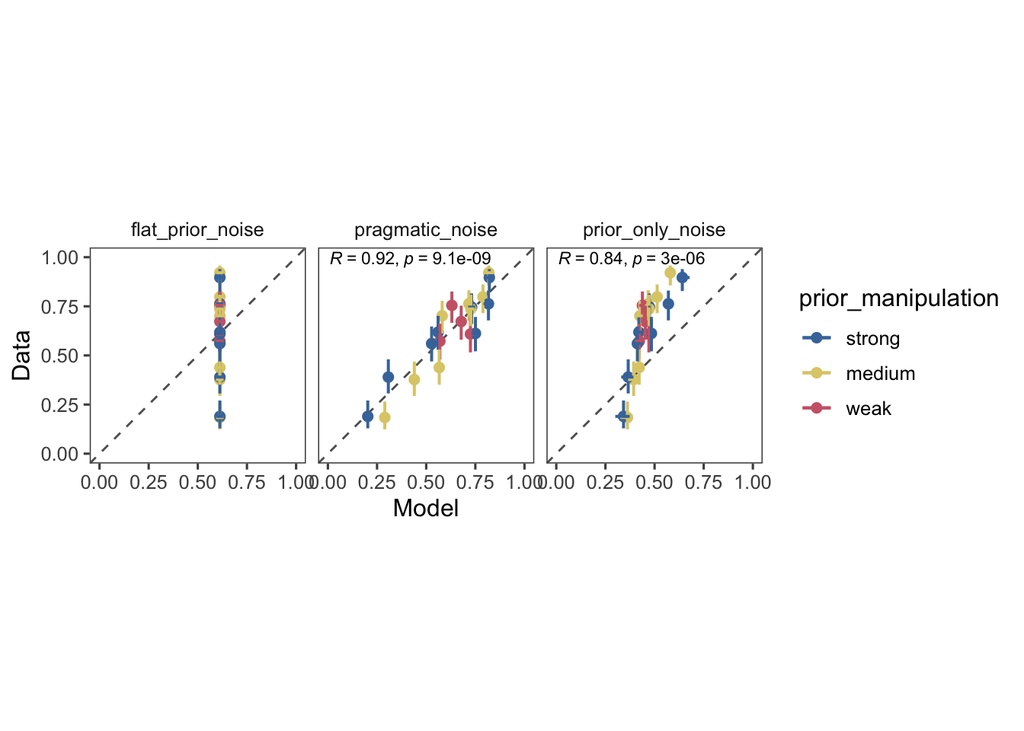

```r
ex_4_cor_plot <- ex_4_pred %>%
  ungroup()%>%
  filter(model != "data") %>%
  left_join(., ex_4_pred %>%
    ungroup()%>%
    filter(model == "data") %>%
    rename(data_mean = mean, data_ci_lower = ci_lower, data_ci_upper = ci_upper) %>%
    select(-model)
  )


ggplot(data = ex_4_cor_plot,aes(x = mean, y = data_mean, col = prior_manipulation)) +
  geom_abline(intercept = 0, slope = 1, lty = 2, alpha = 0.7, size = 0.5)+
  geom_point(size = 2)+
  geom_errorbar(aes(ymin = data_ci_lower, ymax = data_ci_upper),width = 0,size = .7)+
  geom_errorbarh(aes(xmin = ci_lower, xmax = ci_upper), height = 0,size = .7)+
  coord_fixed()+
  xlim(0,1)+ylim(0,1)+
  xlab("Model")+
  ylab("Data")+
  facet_grid ( ~ model) +
  stat_cor(method = "pearson", label.x = 0.01, label.y = 0.99, aes(x = mean, y = data_mean), inherit.aes = F, size = 3)+
  theme_few(base_size = ) +
  scale_colour_ptol()
```

### Model comparison

#### Marginal likelihoods

##### Integration model

```r
loglike.rsa.ex4.noise <-'
var allParams = dataFromR.allParams
var allData = dataFromR.allData

var model = function(){

   var noise = uniformDrift({a: 0, b:1, width: 0.1})

  var conditionOutput = map(function(conditionInfo){

 var conditionSpecificData =  _.filter(allData, {common_ground_manipulation: conditionInfo.common_ground_manipulation, prior_manipulation: conditionInfo.prior_manipulation, speaker: conditionInfo.speaker, alignment: conditionInfo.alignment})

   var conditionSpecificPriors = [1 - conditionInfo.prior, 1 - conditionInfo.prior, conditionInfo.prior]

      var modelPredictions = pragmaticListener({label: "dax", point: 2 }, conditionSpecificPriors, conditionInfo.speak_opt)

   var noisyModelPredictions = addNoise(modelPredictions, noise)

    var loglike = Binomial({
        p: Math.exp(noisyModelPredictions.score(1)),
        n: conditionSpecificData.length}).score(
      sum(_.map(conditionSpecificData, "correct_inf"))
    )
  return  loglike

}, allParams)

 return sum(conditionOutput)

}
'
```

```r
# ex4_pragm_model_noise_loglike <- webppl(
#   program_code = paste(rsaUtils, rsaModel, loglike.rsa.ex4.noise, sep='\n'),
#   data = list(allData = adult_ex4_data, allParams = model_params_ex4),
#   data_var = "dataFromR",
#   model_var = "model",
#   chains = 4,
#   cores = 4,
#   inference_opts = list(method = "forward", samples = 5000)
# ) %>%
#   saveRDS("../../stats/saves/ex4_pragm_model_noise_loglike.rds")

ex4_pragm_model_noise_loglike <- readRDS("../../stats/saves/ex4_pragm_model_noise_loglike.rds")%>%
  mutate(model = "pragmatic_noise")%>%
  group_by(model)%>%
  summarize(logP = logSumExp(value))
```

##### No informativeness model

```r
loglike.prior.only.ex4.noise <-'
var allParams = dataFromR.allParams
var allData = dataFromR.allData

var model = function(){

   var noise = uniformDrift({a: 0, b:1, width: 0.1})

  var conditionOutput = map(function(conditionInfo){

 var conditionSpecificData =  _.filter(allData, {common_ground_manipulation: conditionInfo.common_ground_manipulation, prior_manipulation: conditionInfo.prior_manipulation, speaker: conditionInfo.speaker, alignment: conditionInfo.alignment})

   var conditionSpecificPriors = [1 - conditionInfo.prior, 1 - conditionInfo.prior, conditionInfo.prior]

  var modelPredictions = Infer({method: "enumerate", model: function(){
      var obj = sample( Categorical({vs: all_objects, ps: conditionSpecificPriors}));
      return obj.shape == "circle" ? 1 : 0
  }})

   var noisyModelPredictions = addNoise(modelPredictions, noise)

    var loglike = Binomial({
        p: Math.exp(noisyModelPredictions.score(1)),
        n: conditionSpecificData.length}).score(
      sum(_.map(conditionSpecificData, "correct_inf"))
    )
  return  loglike

}, allParams)

 return sum(conditionOutput)

}
'
```

```r
# ex4_prior_only_model_noise_loglike <- webppl(
#   program_code = paste(rsaUtils, rsaModel, loglike.prior.only.ex4.noise, sep='\n'),
#   data = list(allData = adult_ex4_data, allParams = model_params_ex4),
#   data_var = "dataFromR",
#   model_var = "model",
#   chains = 4,
#   cores = 4,
#   inference_opts = list(method = "forward", samples = 5000)
# ) %>%
#   saveRDS("../../stats/saves/ex4_prior_only_model_noise_loglike.rds")

ex4_prior_only_model_noise_loglike <- readRDS("../../stats/saves/ex4_prior_only_model_noise_loglike.rds")%>%
  mutate(model = "prior_only_noise")%>%
  group_by(model)%>%
  summarize(logP = logSumExp(value))
```

##### No common ground model

```r
loglike.flat.prior.ex4.noise <-'
var allParams = dataFromR.allParams
var allData = dataFromR.allData

var model = function(){

   var noise = uniformDrift({a: 0, b:1, width: 0.1})

  var conditionOutput = map(function(conditionInfo){

 var conditionSpecificData =  _.filter(allData, {common_ground_manipulation: conditionInfo.common_ground_manipulation, prior_manipulation: conditionInfo.prior_manipulation, speaker: conditionInfo.speaker, alignment: conditionInfo.alignment})

   var conditionSpecificPriors = [.5, .5,.5]

      var modelPredictions = pragmaticListener({label: "dax", point: 2 }, conditionSpecificPriors, conditionInfo.speak_opt)

   var noisyModelPredictions = addNoise(modelPredictions, noise)

    var loglike = Binomial({
        p: Math.exp(noisyModelPredictions.score(1)),
        n: conditionSpecificData.length}).score(
      sum(_.map(conditionSpecificData, "correct_inf"))
    )
  return  loglike

}, allParams)

 return sum(conditionOutput)

}
'
```

```r
# ex4_flat_prior_model_noise_loglike <- webppl(
#   program_code = paste(rsaUtils, rsaModel, loglike.flat.prior.ex4.noise, sep='\n'),
#   data = list(allData = adult_ex4_data, allParams = model_params_ex4),
#   data_var = "dataFromR",
#   model_var = "model",
#   chains = 4,
#   cores = 4,
#   inference_opts = list(method = "forward", samples = 5000)
# ) %>%
#   saveRDS("../../stats/saves/ex4_flat_prior_model_noise_loglike.rds")

ex4_flat_prior_model_noise_loglike <- readRDS("../../stats/saves/ex4_flat_prior_model_noise_loglike.rds")%>%
  mutate(model = "flat_prior_noise")%>%
  group_by(model)%>%
  summarize(logP = logSumExp(value))
```

```r
ex4_model_comparison <- bind_rows(
  ex4_pragm_model_noise_loglike,
  ex4_flat_prior_model_noise_loglike,
  ex4_prior_only_model_noise_loglike
)%>%
  mutate(model = reorder(model,logP))
```

#### Plot for likelihoods

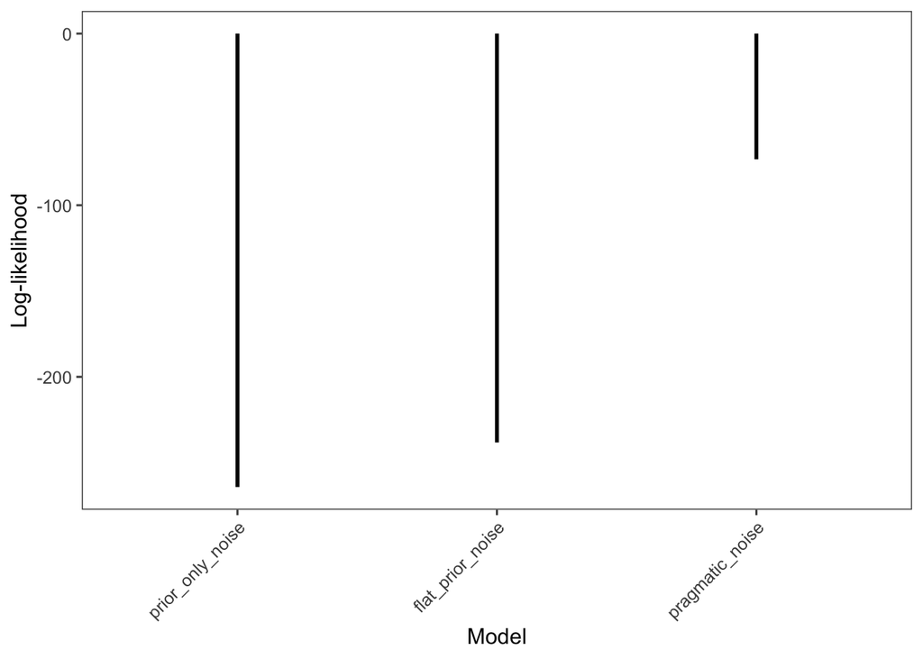

```r
ggplot(ex4_model_comparison, aes(x = model, y = logP, col = model))+
  geom_segment( aes(x=model, xend=model, y=logP, yend=0), col = "black", size = 1)+
  geom_point(size = 7)+
  theme_few()+
  xlab("Model")+
  ylab("Log-likelihood")+
  theme(axis.text.x=element_text(angle = 45, vjust = 1, hjust = 1))+
  guides(col = F)+
  scale_color_manual(breaks=c("pragmatic","prior_only","flat_prior"),
                    values= c("#859900","#b58900","#6c71c4"))
```

#### Bayes factors

```r
ex4_bf <- bind_rows(
  ex4_pragm_model_noise_loglike,
  ex4_flat_prior_model_noise_loglike,
  ex4_prior_only_model_noise_loglike
) %>% spread(model, logP) %>%
  mutate("pragmatic_noise > flat_prior_noise" = exp(pragmatic_noise - flat_prior_noise),
         "pragmatic_noise > prior_only_noise" = exp(pragmatic_noise - prior_only_noise),
         "flat_prior_noise > prior_only_noise" = exp(flat_prior_noise - prior_only_noise)) %>%
  select(-pragmatic_noise,  -flat_prior_noise, -prior_only_noise)

ex4_bf %>%
  kable(digits = 2)
```

| pragmatic_noise > flat_prior_noise | pragmatic_noise > prior_only_noise | flat_prior_noise > prior_only_noise |
| --- | --- | --- |
| 4.65871e+71 | 8.869306e+82 | 190381134774 |

# Children

## Model parameters and data

```r
# children ex3 data
child_ex3_data <-read_csv(file="../../stats/data/child_ex3.csv")
```

```r
# load data from ex1 manipulation experiments to set speaker optimality parameter
child_ex1_data <-read_csv(file="../../stats/data/child_ex1.csv")
# load data from ex2 experiment to set priors
child_ex2_data <-read_csv(file="../../stats/data/child_ex2.csv")
```

#### Inferring speaker optimality parameter and priors

```r
# The prior on the speaker optimality intercept is the same as for the adult speaker optimality parameter.

childModelParam <- '
var prefData = dataFromR.prefData
var infData = dataFromR.infData

var all_conditions = levels(prefData, "condition")

var model  = function(){

  var so_slope = sample(Cauchy({location: 0, scale: 2}))
  var so_int = sample(Cauchy({location: 1, scale: 2}))

  foreach(function(row){

  var age = row.age_num
  var speakerOptimality = so_int  + so_slope * (age - infData[0].minage)

    var inf_priorProbs = [.5, .5, .5]

  var rsaPredictions = pragmaticListener({label: "dax", point: 2 },
   inf_priorProbs, speakerOptimality)
   observe(rsaPredictions, row.correct)

  }, infData)


  var pref_params = map(function(cndtn){

    var conditionData = _.filter(prefData, {condition: cndtn})

    var pref_slope = uniformDrift({a: -2, b: 2, width: 0.4})
    var pref_int = uniformDrift({a: -2, b: 2, width: 0.4})

    foreach(function(row){

      var age = row.age_num

      var priorReg = logistic(pref_int + pref_slope * (age - row.minage))
      var priorProbs= [1-priorReg, priorReg]

      var priorPredictions = Infer({method: "enumerate", model: function(){
      var obj = sample( Categorical({vs: prior_objects, ps: priorProbs}));
      return obj.shape == "circle" ? 1 : 0
      }})

      observe(priorPredictions, row.correct)

    }, conditionData)

    return [
      {param: "pref_int", val: pref_int, condition: cndtn},
      {param: "pref_slope", val: pref_slope, condition: cndtn}
    ]

  }, all_conditions)


  return _.flatten(pref_params).concat(
    [
      { param: "so_slope", val: so_slope},
      { param: "so_int", val: so_int}
    ]
  )
}
'
```

```r
# child_model_param<- webppl(
#   program_code = paste(rsaUtils, rsaModel, childModelParam , sep='\n'),
#   data = list(prefData = child_ex2_data, infData = child_ex1_data),
#   data_var = "dataFromR",
#   model_var = "model",
#   chains = 4,
#   cores = 4,
#   inference_opts = list(method = "MCMC", samples = 6000, burn = 2000, verbose = T)
# )%>%
#   saveRDS("../../stats/saves/child_model_param.rds")


child_model_param <- readRDS("../../stats/saves/child_model_param.rds")%>%
  select(value) %>%
  map_df(bind_rows)%>%
  group_by(param,condition)%>%
  summarise(param_map = estimate_mode(val))%>%
  mutate(cond = paste(param,condition, sep = "_"))%>%
  ungroup()%>%
  select(cond,param_map)%>%
  spread(cond,param_map)%>%
  rename(so_int = so_int_NA,
         so_slope = so_slope_NA)
```

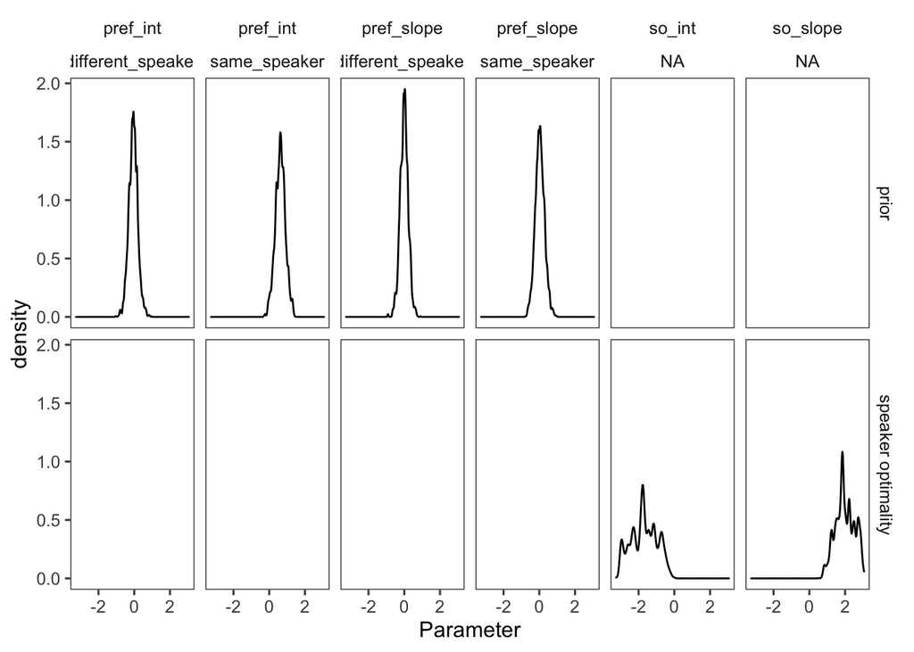

```r
# visualize inferred parameter
plot_child_model_param <- readRDS("../../stats/saves/child_model_param.rds")%>%
  select(value)%>%
  map_df(bind_rows)%>%
  mutate(type = ifelse(grepl("pref",param),"prior", "speaker optimality"))

ggplot(plot_child_model_param, aes(val))+
  geom_density()+
  xlab("Parameter")+
  facet_grid(type~param+condition)+
  theme_few()
```

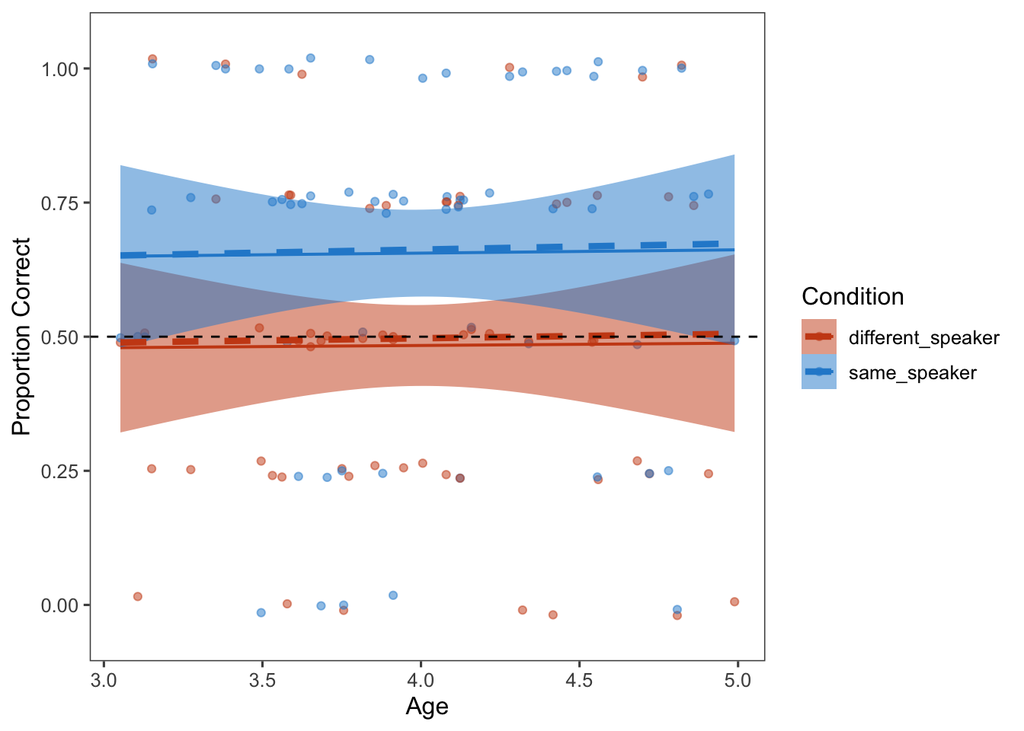

```r
# visualize model priors in comparison to data
child_prior_plot <- child_ex2_data %>%
  group_by(id,age_num,minage,condition)%>%
  summarise(correct = mean(correct))%>%
  mutate(model = ifelse(condition == "different_speaker",
                        plogis(child_model_param$pref_int_different_speaker + child_model_param$pref_slope_different_speaker * (age_num-minage)),
                        plogis(child_model_param$pref_int_same_speaker + child_model_param$pref_slope_same_speaker * (age_num-minage)
                        )))

ggplot(data = child_prior_plot, aes(x = age_num, y = correct, col = condition)) +
  geom_jitter(alpha = 0.5, height = 0.02, width = 0)+
  geom_smooth(aes(fill = condition),method = "lm", se = T, alpha = .5, size = .7)+
  geom_line(aes(x = age_num, y = model, col = condition), size = 1.5, lty = 2)+
  geom_hline(yintercept = 0.5, lty=2)+
  labs(x="Age",y="Proportion Correct")+
  theme_few() +
  ylim(-0.05,1.05)+
  guides(alpha = F)+
  scale_color_solarized(name = "Condition")+
  scale_fill_solarized(name = "Condition")
```

```r
# dashed line represents the developmental trajectories based on the estimated parameters
```

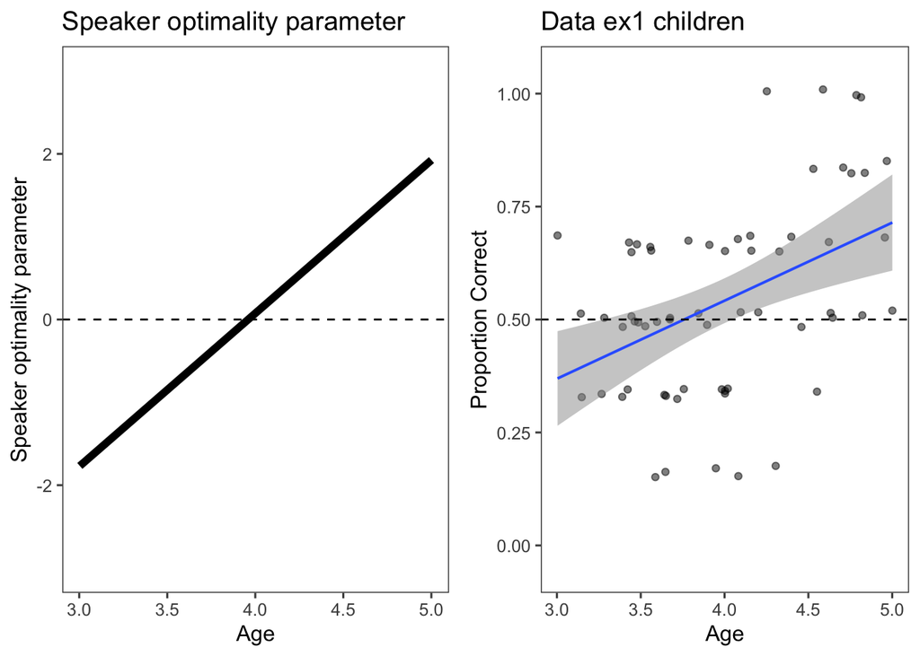

```r
# visualize speaker optimality in comparison to data
child_so_plot <- child_ex1_data %>%
  group_by(id,age_num,minage)%>%
  summarise(correct = mean(correct))%>%
  mutate(model = child_model_param$so_int + child_model_param$so_slope * (age_num - minage))

plot_child_so <- ggplot(data = child_so_plot, aes(x = age_num, y = model)) +
  geom_hline(yintercept = 0, lty=2)+
  geom_line( size = 2)+
  labs(x="Age",y="Speaker optimality parameter")+
  theme_few() +
  ggtitle("Speaker optimality parameter")+
  ylim(-3,3)+
  guides(alpha = F)


plot_ex1_child <-child_ex1_data %>%
  group_by(age_num, id) %>%
  summarise(correct = mean(correct))%>%
  ggplot(data = ., aes(x = age_num, y = correct)) +
  geom_jitter(alpha = 0.5, height = 0.02, width = 0)+
  geom_smooth(method = "lm", se = T, alpha = .5, size = .7)+
  geom_hline(yintercept = 0.5, lty=2)+
  labs(x="Age",y="Proportion Correct")+
  ggtitle("Data ex1 children")+
  theme_few() +
  ylim(-0.05,1.05)+
  guides(alpha = F)

ggarrange(plot_child_so,plot_ex1_child)
```

```r
ex3_model_data <- child_ex3_data%>%
  mutate(so_int = child_model_param$so_int,
         so_slope = child_model_param$so_slope,
         pref_int_different_speaker = child_model_param$pref_int_different_speaker,
         pref_slope_different_speaker = child_model_param$pref_slope_different_speaker,
         pref_int_same_speaker = child_model_param$pref_int_same_speaker,
         pref_slope_same_speaker = child_model_param$pref_slope_same_speaker,
         so = so_int+so_slope*(age_num-min(age_num)),
         diff_prior = plogis(pref_int_different_speaker+pref_slope_different_speaker*(age_num-min(age_num))),
         same_prior = plogis(pref_int_same_speaker+pref_slope_same_speaker*(age_num-min(age_num))))%>%
  group_by(id,trial)%>%
        mutate(priorProbs = ifelse(speaker == "same_speaker" & alignment == "congruent",
                                   list(c(1-same_prior,1-same_prior,same_prior)),
                                   ifelse(speaker == "different_speaker" & alignment == "congruent",
                                          list(c(1-diff_prior,1-diff_prior,diff_prior)),
                                          ifelse(speaker == "same_speaker" & alignment == "incongruent",
                                                 list(c(same_prior,same_prior,1-same_prior)),
                                                 list(c(diff_prior,diff_prior,1-diff_prior))
                                   ))))%>%
  ungroup()%>%
  select(speaker,age_num,minage,alignment,so,priorProbs,correct_inf)
```

## Model predictions

### Integration model

#### Parameter free

```r
child.ex3.rsa.predictions <-'

var allData = dataFromR.allData

var output = map(function(row){

    var modelPredictions = pragmaticListener({label: "dax", point: 2 }, row.priorProbs,row.so)

    return extend([row.age_num + "/" + row.speaker + "/" + row.alignment + "/" + row.correct_inf, Math.exp(modelPredictions.score(1))])

}, allData)

output

'
```

```r
child_ex3_pragm_model<- webppl(
  program_code = paste(rsaUtils, rsaModel, child.ex3.rsa.predictions , sep='\n'),
  data =list(allData = ex3_model_data),
  data_var = "dataFromR"
)

# model predictions
child_ex3_pragm_model_predictions <- child_ex3_pragm_model %>%
  separate(`0`, into = c("age", "speaker", "alignment","correct"), sep="/")%>%
  mutate(mean = `1`,
         ci_lower = mean,
         ci_upper = mean,
         model="pragmatic",
         age = as.numeric(age))%>%
  select(-`1`)
```

#### Noise parameter

```r
child.ex3.rsa.predictions.noise <-'

var allData = dataFromR.allData

var model = function(){

  var noise = uniformDrift({a: 0, b: 1, width: 0.1})

  var output = map(function(row){

    var modelPredictions = pragmaticListener({label: "dax", point: 2 }, row.priorProbs,row.so)

    var noisyModelPredictions = addNoise(modelPredictions, noise)

    observe(noisyModelPredictions, row.correct_inf)

    return  [row.age_num + "/" + row.speaker + "/" + row.alignment, Math.exp(noisyModelPredictions.score(1))]

}, allData)

 return extend(_.fromPairs(output), {noise: noise})

}
'
```

```r
# child_ex3_pragm_model_noise<- webppl(
#   program_code = paste(rsaUtils, rsaModel, child.ex3.rsa.predictions.noise , sep='\n'),
#   data =list(allData = ex3_model_data),
#   data_var = "dataFromR",
#   model_var = "model",
#   chains = 4,
#   cores = 4,
#   inference_opts = list(method = "MCMC", samples = 6000, burn = 2000, verbose = T)
# )%>%
#    saveRDS("../../stats/saves/child_ex3_pragm_model_noise.rds")


# model predictions
child_ex3_pragm_model_predictions_noise <- readRDS("../../stats/saves/child_ex3_pragm_model_noise.rds") %>%
  filter(!(Parameter %in% c("noise"))) %>%
  separate(Parameter, into = c("age", "speaker", "alignment"), sep="/")%>%
  mutate(model = "pragmatic_noise")%>%
  group_by(model, age,alignment,speaker) %>%
  summarise(mean = estimate_mode(value),
            ci_lower = hdi_lower(value),
            ci_upper =hdi_upper(value))%>%
  ungroup()%>%
  mutate(age = as.numeric(age))

## noise parameter
child_ex3_pragm_model_noise_param <- readRDS("../../stats/saves/child_ex3_pragm_model_noise.rds") %>%
  filter(Parameter %in% c("noise"))  %>%
  summarise(mean = estimate_mode(value),
            ci_lower = hdi_lower(value),
            ci_upper = hdi_upper(value))
```

#### Developmental noise parameter

```r
child.ex3.rsa.predictions.developmental.noise <-'

var allData = dataFromR.allData

var model = function(){

  var noise_slope = uniformDrift({a: -5, b: 5, width: 0.2})
  var noise_int = uniformDrift({a: -5, b: 5, width: 0.1})

  var output = map(function(row){

    var noise = logistic(noise_int + noise_slope * (row.age_num-row.minage))

    var modelPredictions = pragmaticListener({label: "dax", point: 2 }, row.priorProbs,row.so)

    var noisyModelPredictions = addNoise(modelPredictions, noise)

    observe(noisyModelPredictions, row.correct_inf)

    return  [row.age_num + "/" + row.speaker + "/" + row.alignment, Math.exp(noisyModelPredictions.score(1))]

}, allData)

 return extend(_.fromPairs(output), {noise_int: noise_int, noise_slope: noise_slope})

}
'
```

```r
# child_ex3_pragm_model_developmental_noise<- webppl(
#   program_code = paste(rsaUtils, rsaModel, child.ex3.rsa.predictions.developmental.noise , sep='\n'),
#   data =list(allData = ex3_model_data),
#   data_var = "dataFromR",
#   model_var = "model",
#   chains = 4,
#   cores = 4,
#   inference_opts = list(method = "MCMC", samples = 6000, burn = 2000, verbose = T)
# )%>%
#    saveRDS("../../stats/saves/child_ex3_pragm_model_developmental_noise.rds")


# model predictions
child_ex3_pragm_model_predictions_developmental_noise <- readRDS("../../stats/saves/child_ex3_pragm_model_developmental_noise.rds") %>%
  filter(!(Parameter %in% c("noise","noise_int","noise_slope"))) %>%
  separate(Parameter, into = c("age", "speaker", "alignment"), sep="/")%>%
  mutate(model = "pragmatic_developmental_noise")%>%
  group_by(model, age,alignment,speaker) %>%
  summarise(mean = estimate_mode(value),
            ci_lower = hdi_lower(value),
            ci_upper =hdi_upper(value))%>%
  ungroup()%>%
  mutate(age = as.numeric(age))

## noise parameter
child_ex3_pragm_model_developmental_noise_param <- readRDS("../../stats/saves/child_ex3_pragm_model_developmental_noise.rds") %>%
  filter(Parameter %in% c("noise_int","noise_slope"))  %>%
  group_by(Parameter)%>%
  summarise(mean = estimate_mode(value),
            ci_lower = hdi_lower(value),
            ci_upper = hdi_upper(value))
```

### No informativeness model

#### Parameter free

```r
child.ex3.prior.only.predictions <-'

var allData = dataFromR.allData

  var output = map(function(row){

      var modelPredictions = Infer({method: "enumerate", model: function(){
      var obj = sample( Categorical({vs: all_objects, ps: row.priorProbs}));
      return obj.shape == "circle" ? 1 : 0
       }})

    return  extend([row.age_num + "/" + row.speaker + "/" + row.alignment+ "/" + row.correct_inf, Math.exp(modelPredictions.score(1))])

}, allData)

 output

'
```

```r
child_ex3_prior_only_model<- webppl(
  program_code = paste(rsaUtils, rsaModel, child.ex3.prior.only.predictions , sep='\n'),
  data =list(allData = ex3_model_data),
  data_var = "dataFromR"
)

# model predictions
child_ex3_prior_only_model_predictions <- child_ex3_prior_only_model %>%
  separate(`0`, into = c("age", "speaker", "alignment","correct"), sep="/")%>%
  mutate(mean = `1`,
         model="prior_only",
         age = as.numeric(age))%>%
  select(-`1`)
```

#### Noise parameter

```r
child.ex3.prior.only.predictions.noise <-'

var allData = dataFromR.allData

var model = function(){

  var noise = uniformDrift({a: 0, b: 1, width: 0.1})

  var output = map(function(row){

      var modelPredictions = Infer({method: "enumerate", model: function(){
      var obj = sample( Categorical({vs: all_objects, ps: row.priorProbs}));
      return obj.shape == "circle" ? 1 : 0
       }})

    var noisyModelPredictions = addNoise(modelPredictions, noise)

    observe(noisyModelPredictions, row.correct_inf)

    return  [row.age_num + "/" + row.speaker + "/" + row.alignment, Math.exp(noisyModelPredictions.score(1))]

}, allData)

 return extend(_.fromPairs(output), {noise: noise})

}
'
```

```r
# child_ex3_prior_only_model_noise<- webppl(
#   program_code = paste(rsaUtils, rsaModel, child.ex3.prior.only.predictions.noise , sep='\n'),
#   data =list(allData = ex3_model_data),
#   data_var = "dataFromR",
#   model_var = "model",
#   chains = 4,
#   cores = 4,
#   inference_opts = list(method = "MCMC", samples = 6000, burn = 2000, verbose = T)
# )%>%
#    saveRDS("../../stats/saves/child_ex3_prior_only_model_noise.rds")


# model predictions
child_ex3_prior_only_model_predictions_noise <- readRDS("../../stats/saves/child_ex3_prior_only_model_noise.rds") %>%
  filter(!(Parameter %in% c("noise"))) %>%
  separate(Parameter, into = c("age", "speaker", "alignment"), sep="/")%>%
  mutate(model = "prior_only_noise")%>%
  group_by(model, age,alignment,speaker) %>%
  summarise(mean = estimate_mode(value),
            ci_lower = hdi_lower(value),
            ci_upper =hdi_upper(value))%>%
  ungroup()%>%
  mutate(age = as.numeric(age))

## noise parameter
child_ex3_prior_only_model_noise_param <- readRDS("../../stats/saves/child_ex3_prior_only_model_noise.rds") %>%
  filter(Parameter %in% c("noise"))  %>%
  summarise(mean = estimate_mode(value),
            ci_lower = hdi_lower(value),
            ci_upper = hdi_upper(value))
```

#### Developmental noise parameter

```r
child.ex3.prior.only.predictions.developmental.noise <-'

var allData = dataFromR.allData

var model = function(){

  var noise_slope = uniformDrift({a: -5, b: 5, width: 0.2})
  var noise_int = uniformDrift({a: -5, b: 5, width: 0.1})

  var output = map(function(row){

    var noise = logistic(noise_int + noise_slope * (row.age_num-row.minage))

      var modelPredictions = Infer({method: "enumerate", model: function(){
      var obj = sample( Categorical({vs: all_objects, ps: row.priorProbs}));
      return obj.shape == "circle" ? 1 : 0
       }})

    var noisyModelPredictions = addNoise(modelPredictions, noise)

    observe(noisyModelPredictions, row.correct_inf)

    return  [row.age_num + "/" + row.speaker + "/" + row.alignment, Math.exp(noisyModelPredictions.score(1))]

}, allData)

 return extend(_.fromPairs(output), {noise_int: noise_int, noise_slope: noise_slope})

}
'
```

```r
# child_ex3_prior_only_model_developmental_noise<- webppl(
#   program_code = paste(rsaUtils, rsaModel, child.ex3.prior.only.predictions.developmental.noise , sep='\n'),
#   data =list(allData = ex3_model_data),
#   data_var = "dataFromR",
#   model_var = "model",
#   chains = 4,
#   cores = 4,
#   inference_opts = list(method = "MCMC", samples = 6000, burn = 2000, verbose = T)
# )%>%
#    saveRDS("../../stats/saves/child_ex3_prior_only_model_developmental_noise.rds")


# model predictions
child_ex3_prior_only_model_predictions_developmental_noise <- readRDS("../../stats/saves/child_ex3_prior_only_model_developmental_noise.rds") %>%
  filter(!(Parameter %in% c("noise_int","noise_slope"))) %>%
  separate(Parameter, into = c("age", "speaker", "alignment"), sep="/")%>%
  mutate(model = "prior_only_developmental_noise")%>%
  group_by(model, age,alignment,speaker) %>%
  summarise(mean = estimate_mode(value),
            ci_lower = hdi_lower(value),
            ci_upper =hdi_upper(value))%>%
  ungroup()%>%
  mutate(age = as.numeric(age))

## noise parameter
child_ex3_prior_only_model_developmental_noise_param <- readRDS("../../stats/saves/child_ex3_prior_only_model_developmental_noise.rds") %>%
  filter(Parameter %in% c("noise_int","noise_slope"))  %>%
  group_by(Parameter)%>%
  summarise(mean = estimate_mode(value),
            ci_lower = hdi_lower(value),
            ci_upper = hdi_upper(value))
```

### No common ground model

#### Parameter free

```r
child.ex3.flat.prior.predictions <-'

var allData = dataFromR.allData

  var output = map(function(row){

    var prior = [.5, .5, .5]

    var modelPredictions = pragmaticListener({label: "dax", point: 2 }, prior,row.so)

    return  extend([row.age_num + "/" + row.speaker + "/" + row.alignment + "/" + row.correct_inf, Math.exp(modelPredictions.score(1))])

}, allData)

output

'
```

```r
child_ex3_flat_prior_model<- webppl(
  program_code = paste(rsaUtils, rsaModel, child.ex3.flat.prior.predictions , sep='\n'),
  data =list(allData = ex3_model_data),
  data_var = "dataFromR")


# model predictions
child_ex3_flat_prior_model_predictions <- child_ex3_flat_prior_model %>%
  separate(`0`, into = c("age", "speaker", "alignment","correct"), sep="/")%>%
  mutate(mean = `1`,
         model="flat_prior",
         age = as.numeric(age))%>%
  select(-`1`)
```

#### Noise parameter

```r
child.ex3.flat.prior.predictions.noise <-'

var allData = dataFromR.allData

var model = function(){

  var noise = uniformDrift({a: 0, b: 1, width: 0.1})

  var output = map(function(row){

    var prior = [.5,.5,.5]

    var modelPredictions = pragmaticListener({label: "dax", point: 2 }, prior,row.so)

    var noisyModelPredictions = addNoise(modelPredictions, noise)

    observe(noisyModelPredictions, row.correct_inf)

    return  [row.age_num + "/" + row.speaker + "/" + row.alignment, Math.exp(noisyModelPredictions.score(1))]

}, allData)

 return extend(_.fromPairs(output), {noise: noise})

}
'
```

```r
# child_ex3_flat_prior_model_noise<- webppl(
#   program_code = paste(rsaUtils, rsaModel, child.ex3.flat.prior.predictions.noise , sep='\n'),
#   data =list(allData = ex3_model_data),
#   data_var = "dataFromR",
#   model_var = "model",
#   chains = 4,
#   cores = 4,
#   inference_opts = list(method = "MCMC", samples = 6000, burn = 2000, verbose = T)
# )%>%
#    saveRDS("../../stats/saves/child_ex3_flat_prior_model_noise.rds")


# model predictions
child_ex3_flat_prior_model_predictions_noise <- readRDS("../../stats/saves/child_ex3_flat_prior_model_noise.rds") %>%
  filter(!(Parameter %in% c("noise"))) %>%
  separate(Parameter, into = c("age", "speaker", "alignment"), sep="/")%>%
  mutate(model = "flat_prior_noise")%>%
  group_by(model, age,alignment,speaker) %>%
  summarise(mean = estimate_mode(value),
            ci_lower = hdi_lower(value),
            ci_upper =hdi_upper(value))%>%
  ungroup()%>%
  mutate(age = as.numeric(age))

## noise parameter
child_ex3_flat_prior_model_noise_param <- readRDS("../../stats/saves/child_ex3_flat_prior_model_noise.rds") %>%
  filter(Parameter %in% c("noise"))  %>%
  summarise(mean = estimate_mode(value),
            ci_lower = hdi_lower(value),
            ci_upper = hdi_upper(value))
```

#### Developmental noise parameter

```r
child.ex3.flat.prior.predictions.developmental.noise <-'

var allData = dataFromR.allData

var model = function(){

  var noise_slope = uniformDrift({a: -5, b: 5, width: 0.2})
  var noise_int = uniformDrift({a: -5, b: 5, width: 0.1})

  var output = map(function(row){

    var noise = logistic(noise_int + noise_slope * (row.age_num-row.minage))

    var prior = [.5,.5,.5]

    var modelPredictions = pragmaticListener({label: "dax", point: 2 }, prior,row.so)

    var noisyModelPredictions = addNoise(modelPredictions, noise)

    observe(noisyModelPredictions, row.correct_inf)

    return  [row.age_num + "/" + row.speaker + "/" + row.alignment, Math.exp(noisyModelPredictions.score(1))]

}, allData)

 return extend(_.fromPairs(output), {noise_int: noise_int, noise_slope: noise_slope})

}
'
```

```r
# child_ex3_flat_prior_model_developmental_noise<- webppl(
#   program_code = paste(rsaUtils, rsaModel, child.ex3.flat.prior.predictions.developmental.noise , sep='\n'),
#   data =list(allData = ex3_model_data),
#   data_var = "dataFromR",
#   model_var = "model",
#   chains = 4,
#   cores = 4,
#   inference_opts = list(method = "MCMC", samples = 6000, burn = 2000, verbose = T)
# )%>%
#    saveRDS("../../stats/saves/child_ex3_flat_prior_model_developmental_noise.rds")


# model predictions
child_ex3_flat_prior_model_predictions_developmental_noise <- readRDS("../../stats/saves/child_ex3_flat_prior_model_developmental_noise.rds") %>%
  filter(!(Parameter %in% c("noise","noise_int","noise_slope"))) %>%
  separate(Parameter, into = c("age", "speaker", "alignment"), sep="/")%>%
  mutate(model = "flat_prior_developmental_noise")%>%
  group_by(model, age,alignment,speaker) %>%
  summarise(mean = estimate_mode(value),
            ci_lower = hdi_lower(value),
            ci_upper =hdi_upper(value))%>%
  ungroup()%>%
  mutate(age = as.numeric(age))

## noise parameter
child_ex3_flat_prior_model_developmental_noise_param <- readRDS("../../stats/saves/child_ex3_flat_prior_model_developmental_noise.rds") %>%
  filter(Parameter %in% c("noise_int","noise_slope"))  %>%
  group_by(Parameter)%>%
  summarise(mean = estimate_mode(value),
            ci_lower = hdi_lower(value),
            ci_upper = hdi_upper(value))
```

## Compare model predictions to data

### Noise parameters

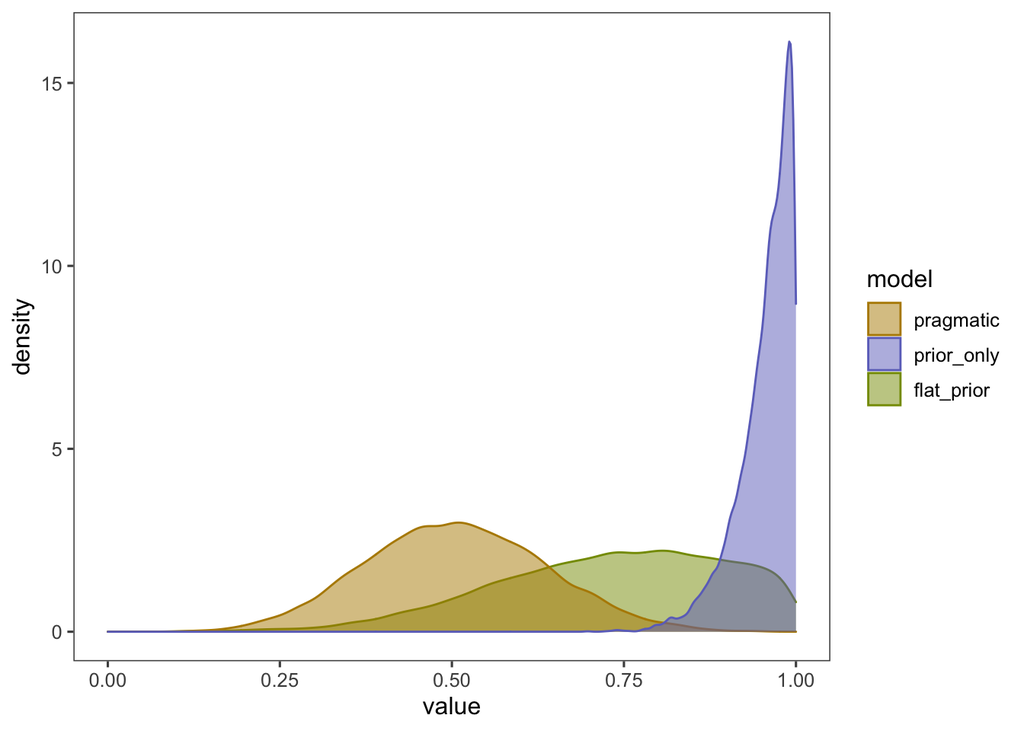

```r
child_noise_parameters <- bind_rows(
  readRDS("../../stats/saves/child_ex3_pragm_model_noise.rds") %>%
  filter(Parameter %in% c("noise"))  %>%
  mutate(model = "pragmatic"),
  readRDS("../../stats/saves/child_ex3_prior_only_model_noise.rds") %>%
  filter(Parameter %in% c("noise"))  %>%
  mutate(model = "prior_only"),
  readRDS("../../stats/saves/child_ex3_flat_prior_model_noise.rds") %>%
  filter(Parameter %in% c("noise"))  %>%
  mutate(model = "flat_prior")
  )

ggplot(child_noise_parameters, aes(x = value, col = model, fill = model))+
  geom_density(alpha = .5)+
  theme_few()+
  xlim(0,1)+
  scale_color_manual(breaks=c("pragmatic","prior_only","flat_prior"),
                    values= c("#b58900","#6c71c4","#859900"))+
  scale_fill_manual(breaks=c("pragmatic","prior_only","flat_prior"),
                    values= c("#b58900","#6c71c4","#859900"))
```

### Developmental noise parameters

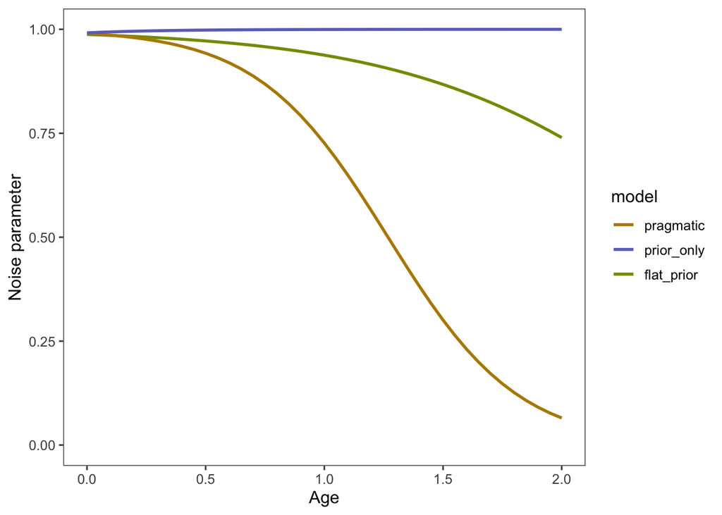

```r
developmental_noise_parameter <- data_frame(
  age = rep(seq(0,2, by = 0.05),3),
  model = c(rep("pragmatic",41),
            rep("flat_prior",41),
            rep("prior_only",41)),
  int = c(rep(child_ex3_pragm_model_developmental_noise_param%>%
                filter(Parameter == "noise_int")%>%
                pull(mean),41),
          rep(child_ex3_flat_prior_model_developmental_noise_param%>%
                filter(Parameter == "noise_int")%>%
                pull(mean),41),
          rep(child_ex3_prior_only_model_developmental_noise_param%>%
                filter(Parameter == "noise_int")%>%
                pull(mean),41)
          ),
  slope = c(rep(child_ex3_pragm_model_developmental_noise_param%>%
                filter(Parameter == "noise_slope")%>%
                pull(mean),41),
          rep(child_ex3_flat_prior_model_developmental_noise_param%>%
                filter(Parameter == "noise_slope")%>%
                pull(mean),41),
          rep(child_ex3_prior_only_model_developmental_noise_param%>%
                filter(Parameter == "noise_slope")%>%
                pull(mean),41))
) %>%
  mutate(y = plogis(int + slope *age))

ggplot(developmental_noise_parameter, aes(x = age, y= y, col = model))+
  geom_line(size = 1)+
  ylab("Noise parameter")+
  xlab("Age")+
  ylim(0,1)+
  theme_few()+
  scale_color_manual(breaks=c("pragmatic","prior_only","flat_prior"),
                    values= c("#b58900","#6c71c4","#859900"))
```

### Plot model predictions and data

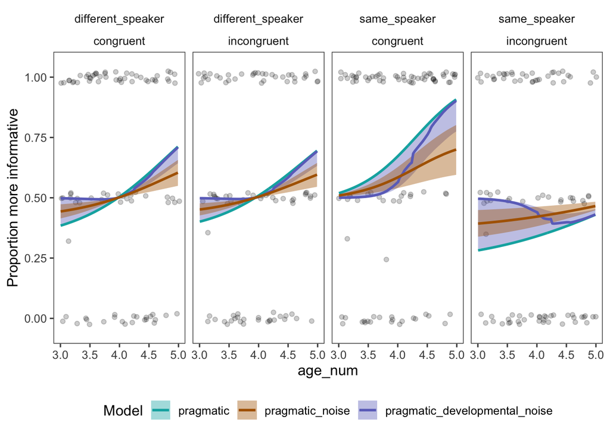

```r
child_model_predictions <- bind_rows(
  child_ex3_pragm_model_predictions_noise,
  child_ex3_pragm_model_predictions_developmental_noise,
  child_ex3_pragm_model_predictions
  #child_ex3_prior_only_model_predictions_noise,
  #child_ex3_flat_prior_model_predictions_noise
  #child_ex3_flat_prior_model_predictions,
  #child_ex3_prior_only_model_predictions
  )


#saveRDS(child_model_predictions, "../../stats/saves/child_ex3_model_predictions.rds")

plot_child_ex3_data <- child_ex3_data%>%
  group_by(age_num,speaker,alignment)%>%
  summarise(mean = mean(correct_inf))

ggplot(child_model_predictions)+
  geom_jitter(data = plot_child_ex3_data, aes(x = age_num, y = mean), width = .025,height = .025, alpha = .2)+
  geom_ribbon(aes(x = age, ymin = ci_lower, ymax = ci_upper, fill = model), alpha = .4) +
  geom_line(aes(x = age, y = mean, col = model), size = 1, alpha = 1, linetype = 1) +
  #geom_smooth(data = child_ex3_data, aes(x = age_num, y = correct_inf), col = "black", size = 0.6, method = "loess", span = 2,  se = T,  alpha = .5)+
  #geom_hline(yintercept = 0.5, lty=2)+
  labs(y="Proportion more informative")+
  ylim(-0.05,1.05)+
  facet_grid(~speaker+alignment)+
  theme_few()+
  theme(legend.position="bottom")+
  scale_color_manual(name="Model",
                     breaks=c("pragmatic","pragmatic_noise","pragmatic_developmental_noise"),
                     values= c("#00afaf","#af6300","#6c71c4"))+
  scale_fill_manual(name="Model",
                     breaks=c("pragmatic","pragmatic_noise","pragmatic_developmental_noise"),
                     values= c("#00afaf","#af6300","#6c71c4"))
```

### Correlation plot model predictions and data

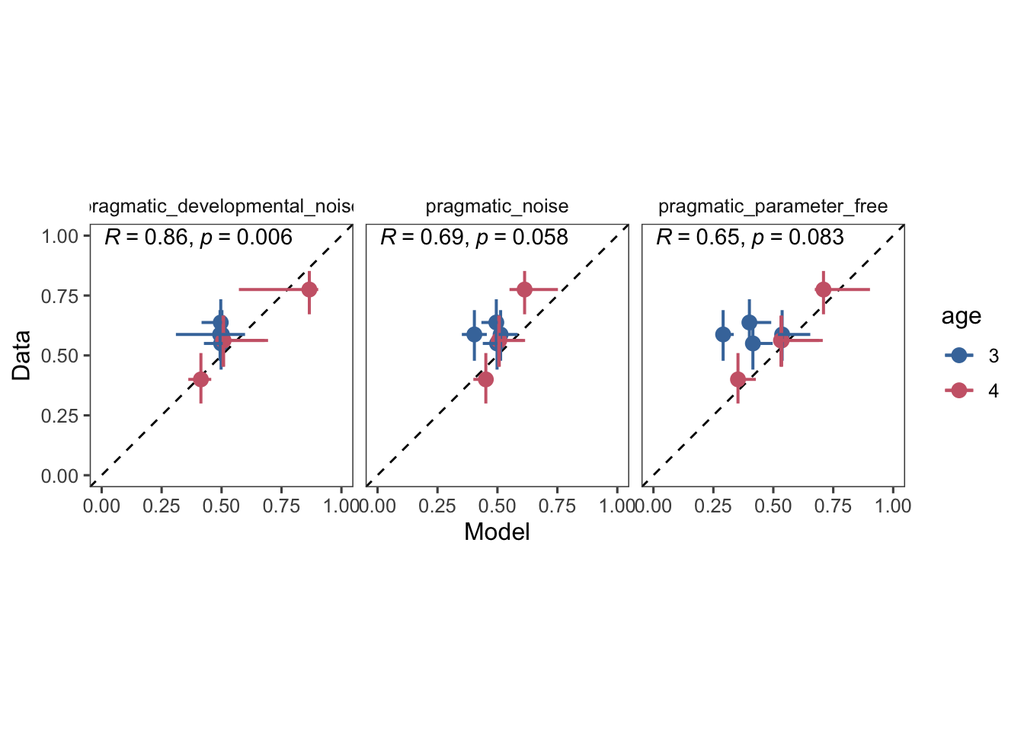

```r
child_cor_data <- child_ex3_data %>%
  group_by(age_bin,speaker, alignment) %>%
  summarize(k = sum(correct_inf), n = n())%>%
  ungroup() %>%
  mutate(a = 1 + k,
         b = 1 + n - k,
         data_ci_lower  = qbeta(.025, a, b),
         data_ci_upper = qbeta(.975, a, b),
         data_mode = (a-1)/(a+b-2))%>%
  select(-a,-b,-n,-k)

child_cor_model <- bind_rows(
  child_ex3_pragm_model %>%
  separate(`0`, into = c("age", "speaker", "alignment","correct"), sep="/")%>%
  mutate(value = `1`,
         model = "pragmatic_parameter_free",
         age = ifelse(age<4,"3","4"))%>%
    group_by(age,model,speaker,alignment)%>%
    summarise(model_mode = estimate_mode(value),
              model_ci_lower = hdi_lower(value),
              model_ci_upper =hdi_upper(value)),
  readRDS("../../stats/saves/child_ex3_pragm_model_noise.rds") %>%
    filter(!(Parameter %in% c("noise"))) %>%
    separate(Parameter, into = c("age", "speaker", "alignment"), sep="/")%>%
    mutate(model = "pragmatic_noise",
           age = ifelse(age<4,"3","4"))%>%
    group_by(age,model,speaker,alignment) %>%
    summarise(model_mode = estimate_mode(value),
              model_ci_lower = hdi_lower(value),
              model_ci_upper =hdi_upper(value)),
  readRDS("../../stats/saves/child_ex3_pragm_model_developmental_noise.rds") %>%
    filter(!(Parameter %in% c("noise","noise_int","noise_slope"))) %>%
    separate(Parameter, into = c("age", "speaker", "alignment"), sep="/")%>%
    mutate(model = "pragmatic_developmental_noise",
           age = ifelse(age<4,"3","4"))%>%
    group_by(age,model,speaker,alignment) %>%
    summarise(model_mode = estimate_mode(value),
              model_ci_lower = hdi_lower(value),
              model_ci_upper =hdi_upper(value))
)


child_cor_plot <- child_cor_model %>%
  ungroup()%>%
  mutate(data_mode = rep(child_cor_data$data_mode,3),
         data_ci_lower = rep(child_cor_data$data_ci_lower,3),
         data_ci_upper  =rep( child_cor_data$data_ci_upper,3))


ggplot(data = child_cor_plot,aes(x = model_mode, y = data_mode, col = age)) +
  geom_abline(intercept = 0, slope = 1, lty = 2, alpha = 1, size = .5)+
  geom_point(size = 3)+
  geom_errorbar(aes(ymin = data_ci_lower, ymax = data_ci_upper),width = 0,size = .7)+
  geom_errorbarh(aes(xmin = model_ci_lower, xmax = model_ci_upper), height = 0,size = .7)+
  coord_fixed()+
  facet_grid(~model)+
  stat_cor(method = "pearson", label.x = 0.01, label.y = 0.99, aes(x = model_mode, y = data_mode), inherit.aes = F)+
  xlim(0,1)+ylim(0,1)+
  xlab("Model")+
  ylab("Data")+
  theme_few() +
  scale_colour_ptol()
```

## Model comparison

### Marginal likelihoods

#### Integration model

##### Parameter free

```r
child.ex3.rsa.marginal.likelihood <-'

var allData = dataFromR.allData

var model = function(){

  var output = map(function(row){

    var modelPredictions = pragmaticListener({label: "dax", point: 2 }, row.priorProbs,row.so)

    observe(modelPredictions, row.correct_inf)

}, allData)

}

var steps = 5000
var samples = 100
var mll = AIS(model, {steps:steps, samples: samples})
mll

'
```

```r
# child_ex3_pragm_model_likelihood<- webppl(
#   program_code = paste(rsaUtils, rsaModel, child.ex3.rsa.marginal.likelihood , sep='\n'),
#   data =list(allData = ex3_model_data),
#   data_var = "dataFromR",
#   chains = 3,
#   cores = 3
# )%>%
#   saveRDS("../../stats/saves/child_ex3_pragm_model_loglike.rds")

child_ex3_pragm_model_likelihood <- readRDS("../../stats/saves/child_ex3_pragm_model_loglike.rds")%>%
  as.tibble()%>%
  mutate(model = "pragmatic",
         parameter = "parameter free")%>%
  group_by(model,parameter)%>%
  summarise(logP = mean(V1))
```

##### Noise parameter

```r
child.ex3.rsa.noise.marginal.likelihood <-'

var allData = dataFromR.allData

var model = function(){

  var noise = uniform({a: 0, b: 1})

  var output = map(function(row){

    var modelPredictions = pragmaticListener({label: "dax", point: 2 }, row.priorProbs,row.so)

    var noisyModelPredictions = addNoise(modelPredictions, noise)

    observe(noisyModelPredictions, row.correct_inf)

}, allData)

}

var steps = 5000
var samples = 100
var mll = AIS(model, {steps:steps, samples: samples})
mll
'
```

```r
# child_ex3_pragm_model_noise_likelihood<- webppl(
#   program_code = paste(rsaUtils, rsaModel, child.ex3.rsa.noise.marginal.likelihood , sep='\n'),
#   data =list(allData = ex3_model_data),
#   data_var = "dataFromR",
#   chains = 3,
#   cores = 3
# )%>%
#   saveRDS("../../stats/saves/child_ex3_pragm_model_noise_loglike.rds")


child_ex3_pragm_model_noise_likelihood <- readRDS("../../stats/saves/child_ex3_pragm_model_noise_loglike.rds")%>%
  as.tibble()%>%
  mutate(model = "pragmatic",
         parameter = "noise")%>%
  group_by(model,parameter)%>%
  summarise(logP = mean(V1))
```

##### Developmental noise parameter

```r
child.ex3.rsa.developmental.noise.marginal.likelihood <-'

var allData = dataFromR.allData

var model = function(){

  var noise_slope = uniformDrift({a: -5, b: 5, width: 0.2})
  var noise_int = uniformDrift({a: -5, b: 5, width: 0.1})

  var output = map(function(row){

    var noise = logistic(noise_int + noise_slope * (row.age_num-row.minage))

    var modelPredictions = pragmaticListener({label: "dax", point: 2 }, row.priorProbs,row.so)

    var noisyModelPredictions = addNoise(modelPredictions, noise)

    observe(noisyModelPredictions, row.correct_inf)

}, allData)

}

var steps = 5000
var samples = 100
var mll = AIS(model, {steps:steps, samples: samples})
mll
'
```

```r
# child_ex3_pragm_model_developmental_noise_likelihood<- webppl(
#   program_code = paste(rsaUtils, rsaModel, child.ex3.rsa.developmental.noise.marginal.likelihood , sep='\n'),
#   data =list(allData = ex3_model_data),
#   data_var = "dataFromR",
#   chains = 3,
#   cores = 3
# )%>%
#   saveRDS("../../stats/saves/child_ex3_pragm_model_developmenatl_noise_loglike.rds")


child_ex3_pragm_model_developmental_noise_likelihood <- readRDS("../../stats/saves/child_ex3_pragm_model_developmenatl_noise_loglike.rds")%>%
  as.tibble()%>%
  mutate(model = "pragmatic",
         parameter = "developmental noise")%>%
  group_by(model,parameter)%>%
  summarise(logP = mean(V1))
```

#### No common ground model

##### Parameter free

```r
child.ex3.flat.prior.marginal.likelihood <-'

var allData = dataFromR.allData

var model = function(){

  var noise = uniform({a: 0, b: 1})

  var output = map(function(row){

    var prior = [.5,.5,.5]

    var modelPredictions = pragmaticListener({label: "dax", point: 2 }, prior,row.so)

    observe(modelPredictions, row.correct_inf)

}, allData)

}

var steps = 5000
var samples = 100
var mll = AIS(model, {steps:steps, samples: samples})
mll
'
```

```r
# child_ex3_flat_prior_model_likelihood<- webppl(
#   program_code = paste(rsaUtils, rsaModel, child.ex3.flat.prior.marginal.likelihood , sep='\n'),
#   data =list(allData = ex3_model_data),
#   data_var = "dataFromR",
#   chains = 3,
#   cores = 3
# )%>%
#   saveRDS("../../stats/saves/child_ex3_flat_prior_model_loglike.rds")

child_ex3_flat_prior_model_likelihood <- readRDS("../../stats/saves/child_ex3_flat_prior_model_loglike.rds")%>%
  as.tibble()%>%
  mutate(model = "flat_prior",
         parameter = "parameter free")%>%
  group_by(model,parameter)%>%
  summarise(logP = mean(V1))
```

##### Noise parameter

```r
child.ex3.flat.prior.noise.marginal.likelihood <-'

var allData = dataFromR.allData

var model = function(){

  var noise = uniform({a: 0, b: 1})

  var output = map(function(row){

    var prior = [.5,.5,.5]

    var modelPredictions = pragmaticListener({label: "dax", point: 2 }, prior,row.so)

    var noisyModelPredictions = addNoise(modelPredictions, noise)

    observe(noisyModelPredictions, row.correct_inf)

}, allData)

}

var steps = 5000
var samples = 100
var mll = AIS(model, {steps:steps, samples: samples})
mll
'
```

```r
# child_ex3_flat_prior_model_noise_likelihood<- webppl(
#   program_code = paste(rsaUtils, rsaModel, child.ex3.flat.prior.noise.marginal.likelihood , sep='\n'),
#   data =list(allData = ex3_model_data),
#   data_var = "dataFromR",
#   chains = 3,
#   cores = 3
# )%>%
#   saveRDS("../../stats/saves/child_ex3_flat_prior_model_noise_loglike.rds")

child_ex3_flat_prior_model_noise_likelihood <- readRDS("../../stats/saves/child_ex3_flat_prior_model_noise_loglike.rds")%>%
  as.tibble()%>%
  mutate(model = "flat_prior",
         parameter = "noise")%>%
  group_by(model,parameter)%>%
  summarise(logP = mean(V1))
```

##### Developmental noise parameter

```r
child.ex3.flat.prior.developmental.noise.marginal.likelihood <-'

var allData = dataFromR.allData

var model = function(){

  var noise_slope = uniformDrift({a: -5, b: 5, width: 0.2})
  var noise_int = uniformDrift({a: -5, b: 5, width: 0.1})

  var output = map(function(row){

    var noise = logistic(noise_int + noise_slope * (row.age_num-row.minage))

    var prior = [.5,.5,.5]

    var modelPredictions = pragmaticListener({label: "dax", point: 2 }, prior,row.so)

    var noisyModelPredictions = addNoise(modelPredictions, noise)

    observe(noisyModelPredictions, row.correct_inf)

}, allData)

}

var steps = 5000
var samples = 100
var mll = AIS(model, {steps:steps, samples: samples})
mll
'
```

```r
# child_ex3_flat_prior_model_developmental_noise_likelihood<- webppl(
#   program_code = paste(rsaUtils, rsaModel, child.ex3.flat.prior.developmental.noise.marginal.likelihood , sep='\n'),
#   data =list(allData = ex3_model_data),
#   data_var = "dataFromR",
#   chains = 3,
#   cores = 3
# )%>%
#   saveRDS("../../stats/saves/child_ex3_flat_prior_model_developmental_noise_loglike.rds")


child_ex3_flat_prior_model_developmental_noise_likelihood <- readRDS("../../stats/saves/child_ex3_flat_prior_model_developmental_noise_loglike.rds")%>%
  as.tibble()%>%
  mutate(model = "flat_prior",
         parameter = "developmental noise")%>%
  group_by(model,parameter)%>%
  summarise(logP = mean(V1))
```

#### No informativeness model

##### Parameter free

```r
child.ex3.prior.only.marginal.likelihood <-'

var allData = dataFromR.allData

var model = function(){

  var noise = uniform({a: 0, b: 1})

  var output = map(function(row){

    var modelPredictions = Infer({method: "enumerate", model: function(){
      var obj = sample( Categorical({vs: all_objects, ps: row.priorProbs}));
      return obj.shape == "circle" ? 1 : 0
       }})

    observe(modelPredictions, row.correct_inf)

}, allData)

}

var steps = 5000
var samples = 100
var mll = AIS(model, {steps:steps, samples: samples})
mll
'
```

```r
# child_ex3_prior_only_model_likelihood<- webppl(
#   program_code = paste(rsaUtils, rsaModel, child.ex3.prior.only.noise.marginal.likelihood , sep='\n'),
#   data =list(allData = ex3_model_data),
#   data_var = "dataFromR",
#   chains = 3,
#   cores = 3
# )%>%
#   saveRDS("../../stats/saves/child_ex3_prior_only_model_loglike.rds")


child_ex3_prior_only_model_likelihood <- readRDS("../../stats/saves/child_ex3_prior_only_model_loglike.rds")%>%
  as.tibble()%>%
  mutate(model = "prior_only",
         parameter = "parameter free")%>%
  group_by(model,parameter)%>%
  summarise(logP = mean(V1))
```

##### Noise parameter

```r
child.ex3.prior.only.noise.marginal.likelihood <-'

var allData = dataFromR.allData

var model = function(){

  var noise = uniform({a: 0, b: 1})

  var output = map(function(row){

    var modelPredictions = Infer({method: "enumerate", model: function(){
      var obj = sample( Categorical({vs: all_objects, ps: row.priorProbs}));
      return obj.shape == "circle" ? 1 : 0
       }})

    var noisyModelPredictions = addNoise(modelPredictions, noise)

    observe(noisyModelPredictions, row.correct_inf)

}, allData)

}

var steps = 5000
var samples = 100
var mll = AIS(model, {steps:steps, samples: samples})
mll
'
```

```r
# child_ex3_prior_only_model_noise_likelihood<- webppl(
#   program_code = paste(rsaUtils, rsaModel, child.ex3.prior.only.noise.marginal.likelihood , sep='\n'),
#   data =list(allData = ex3_model_data),
#   data_var = "dataFromR",
#   chains = 3,
#   cores = 3
# )%>%
#   saveRDS("../../stats/saves/child_ex3_prior_only_model_noise_loglike.rds")


child_ex3_prior_only_model_noise_likelihood <- readRDS("../../stats/saves/child_ex3_prior_only_model_noise_loglike.rds")%>%
  as.tibble()%>%
  mutate(model = "prior_only",
         parameter = "noise")%>%
  group_by(model,parameter)%>%
  summarise(logP = mean(V1))
```

##### Developmental noise parameter

```r
child.ex3.prior.only.developmental.noise.marginal.likelihood <-'

var allData = dataFromR.allData

var model = function(){

  var noise_slope = uniformDrift({a: -5, b: 5, width: 0.2})
  var noise_int = uniformDrift({a: -5, b: 5, width: 0.1})

  var output = map(function(row){

    var noise = logistic(noise_int + noise_slope * (row.age_num-row.minage))

    var modelPredictions = Infer({method: "enumerate", model: function(){
      var obj = sample( Categorical({vs: all_objects, ps: row.priorProbs}));
      return obj.shape == "circle" ? 1 : 0
       }})

    var noisyModelPredictions = addNoise(modelPredictions, noise)

    observe(noisyModelPredictions, row.correct_inf)

}, allData)

}

var steps = 5000
var samples = 100
var mll = AIS(model, {steps:steps, samples: samples})
mll
'
```

```r
# child_ex3_prior_only_model_developmental_noise_likelihood<- webppl(
#   program_code = paste(rsaUtils, rsaModel, child.ex3.prior.only.developmental.noise.marginal.likelihood , sep='\n'),
#   data =list(allData = ex3_model_data),
#   data_var = "dataFromR",
#   chains = 3,
#   cores = 3
# )%>%
#   saveRDS("../../stats/saves/child_ex3_prior_only_model_developmental_noise_loglike.rds")


child_ex3_prior_only_model_developmental_noise_likelihood <- readRDS("../../stats/saves/child_ex3_prior_only_model_developmental_noise_loglike.rds")%>%
  as.tibble()%>%
  mutate(model = "prior_only",
         parameter = "developmental noise")%>%
  group_by(model,parameter)%>%
  summarise(logP = mean(V1))
```

```r
# calculating model log-likelihoods

# child_ex3_model_comparison <- bind_rows(
#   child_ex3_pragm_model_likelihood,
#   child_ex3_pragm_model_noise_likelihood,
#   child_ex3_pragm_model_developmental_noise_likelihood,
#   child_ex3_flat_prior_model_noise_likelihood,
#   child_ex3_flat_prior_model_likelihood,
#   child_ex3_flat_prior_model_developmental_noise_likelihood,
#   child_ex3_prior_only_model_noise_likelihood,
#   child_ex3_prior_only_model_likelihood,
#   child_ex3_prior_only_model_developmental_noise_likelihood
# )%>%
#   ungroup()%>%
#   mutate(model = reorder(model,logP))%>%
#   saveRDS("../../stats/saves/child_ex3_model_comparison.rds")

child_ex3_model_comparison <- readRDS("../../stats/saves/child_ex3_model_comparison.rds")
```

### Plot for likelihoods

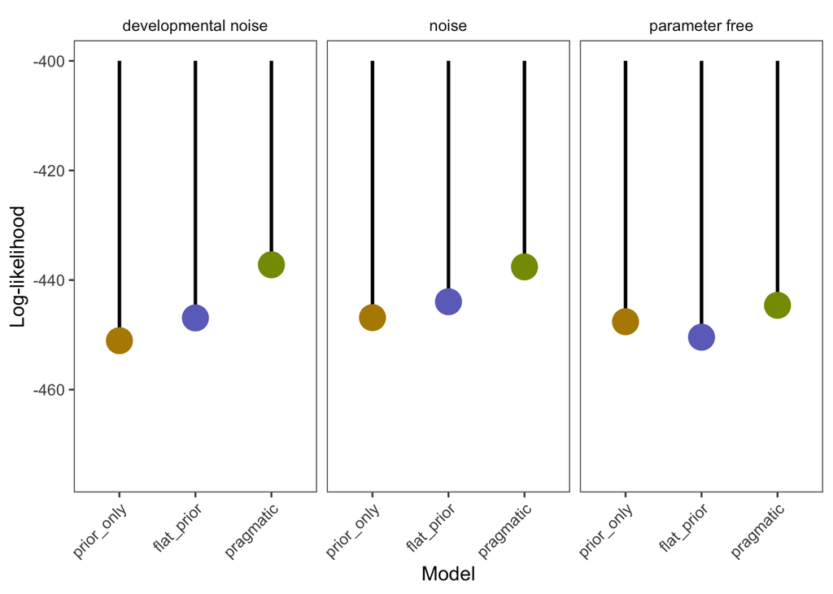

```r
ggplot(child_ex3_model_comparison, aes(x = model, y = logP, col = model))+
  geom_segment( aes(x=model, xend=model, y=-400, yend=logP), col = "black", size = 1)+
  geom_point(size = 7)+
  theme_few()+
  xlab("Model")+
  ylab("Log-likelihood")+
  theme(axis.text.x=element_text(angle = 45, vjust = 1, hjust = 1))+
  guides(col = F)+
  facet_grid(~parameter)+
  ylim(-475,-400)+
  scale_color_manual(breaks=c("pragmatic","prior_only","flat_prior"),
                    values= c("#859900","#b58900","#6c71c4"))
```

### Bayes factors

```r
child_ex3_pragmatic_models_bf <- child_ex3_model_comparison%>%
  filter(model == "pragmatic")%>%
  spread(parameter, logP) %>%
  mutate("dev. noise > noise" = exp(`developmental noise` - noise),
         "noise > parameter free" = exp(noise - `parameter free`),
         "dev. noise > parameter free" = exp(`developmental noise` - `parameter free`)) %>%
  select(-`parameter free`,-`developmental noise`, -noise)

child_ex3_pragmatic_models_bf%>%
  kable(digits = 2)
```

| model | dev. noise > noise | noise > parameter free | dev. noise > parameter free |
| --- | --- | --- | --- |
| pragmatic | 1.46 | 1117.56 | 1635.14 |

```r
child_ex3_bf <- child_ex3_model_comparison%>%
  group_by(parameter)%>%
  spread(model, logP) %>%
  mutate("pragmatic > flat_prior" = exp(pragmatic - flat_prior),
         "pragmatic > prior_only" = exp(pragmatic - prior_only),
         "flat_prior > prior_only" = exp(flat_prior - prior_only)) %>%
  select(-pragmatic,-flat_prior, -prior_only)

child_ex3_bf%>%
  kable(digits = 2)
```

| parameter | pragmatic > flat_prior | pragmatic > prior_only | flat_prior > prior_only |
| --- | --- | --- | --- |
| developmental noise | 16360.98 | 1034803.89 | 63.25 |
| noise | 577.39 | 10560.09 | 18.29 |
| parameter free | 334.05 | 19.88 | 0.06 |